# Number of statements

## Ile z mównicy ile z sali?

Load: [`archivist::aread('mi2-warsaw/sejmRP/UseCase/arepo/68ab87994d098f57d31acb0b892da0ee')`](https://raw.githubusercontent.com/mi2-warsaw/sejmRP/master/UseCase/arepo/gallery/68ab87994d098f57d31acb0b892da0ee.rda)

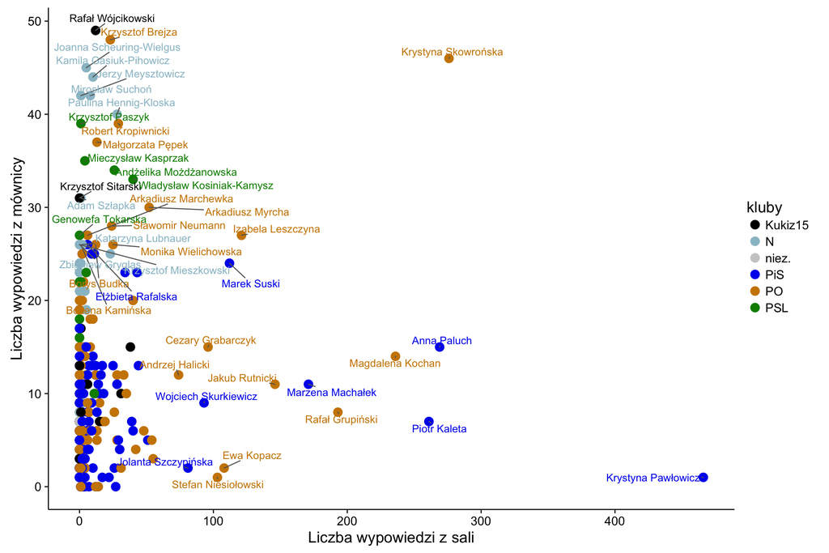

Load: [`archivist::aread('mi2-warsaw/sejmRP/UseCase/arepo/6731edeb0fb9d11308cd4e095ef6e269')`](https://raw.githubusercontent.com/mi2-warsaw/sejmRP/master/UseCase/arepo/gallery/6731edeb0fb9d11308cd4e095ef6e269.rda)

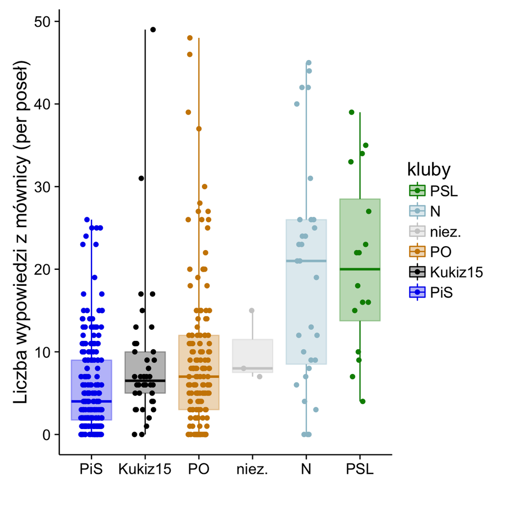

Load: [`archivist::aread('mi2-warsaw/sejmRP/UseCase/arepo/ea499688b2696005d19fb1a8a52b8b67')`](https://raw.githubusercontent.com/mi2-warsaw/sejmRP/master/UseCase/arepo/gallery/ea499688b2696005d19fb1a8a52b8b67.rda)

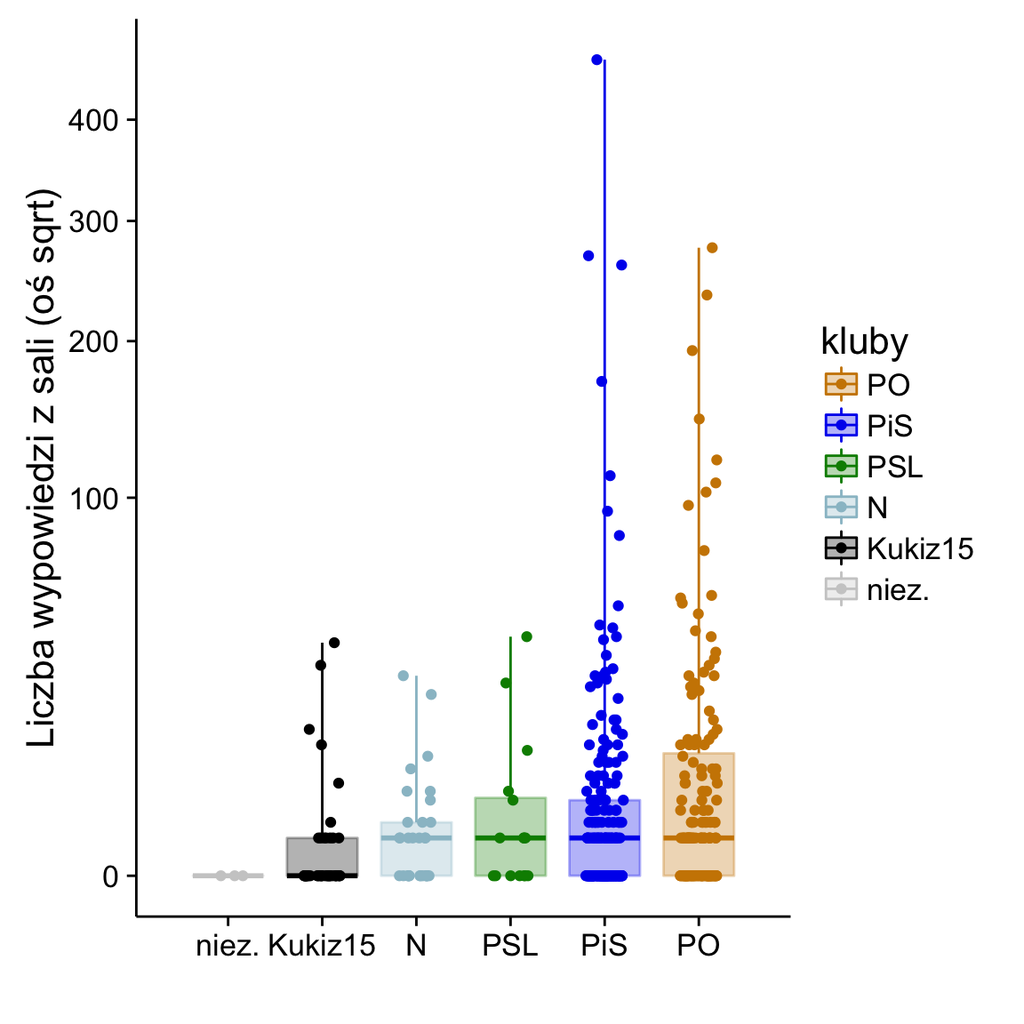

## Wtrącenia z sali

|  | surname_name | o podatku od niektórych instytucji finansowych | o Policji | o radiofonii i telewizji | o rządowym projekcie ustawy budżetowej | o służbie cywilnej | o systemie oświaty | o Trybunale Konstytucyjnym | polskiej polityki zagranicznej | Trybunału Konstytucyjnego | w wychowywaniu dzieci | wszystko | kluby |
| --- | --- | --- | --- | --- | --- | --- | --- | --- | --- | --- | --- | --- | --- |
| 18 | Krystyna Pawłowicz | 0 | 4 | 57 | 58 | 7 | 6 | 70 | 0 | 75 | 61 | 466 | PiS |
| 19 | Krystyna Skowrońska | 7 | 1 | 7 | 29 | 5 | 11 | 16 | 11 | 5 | 42 | 276 | PO |
| 4 | Anna Paluch | 1 | 0 | 5 | 8 | 6 | 3 | 52 | 45 | 7 | 114 | 269 | PiS |
| 25 | Piotr Kaleta | 0 | 4 | 65 | 29 | 7 | 23 | 24 | 0 | 2 | 66 | 261 | PiS |
| 70 | Magdalena Kochan | 9 | 0 | 6 | 21 | 0 | 4 | 39 | 0 | 32 | 56 | 236 | PO |
| 26 | Rafał Grupiński | 0 | 4 | 11 | 14 | 1 | 7 | 42 | 1 | 35 | 20 | 193 | PO |
| 24 | Marzena Machałek | 0 | 1 | 14 | 17 | 4 | 57 | 11 | 2 | 6 | 16 | 171 | PiS |
| 57 | Jakub Rutnicki | 0 | 0 | 17 | 3 | 0 | 12 | 18 | 1 | 5 | 28 | 146 | PO |
| 55 | Izabela Leszczyna | 4 | 0 | 29 | 28 | 0 | 21 | 0 | 1 | 0 | 2 | 121 | PO |
| 77 | Marek Suski | 1 | 2 | 25 | 6 | 0 | 0 | 8 | 0 | 4 | 33 | 112 | PiS |

[output cut: 233 more lines]

Poseł Adam Abramowicz: 3 x 15.

Poseł Adam Abramowicz: A to prawda.

Poseł Adam Abramowicz: Ale niech nie kłamie. Proszę nie kłamać.

Poseł Adam Abramowicz: Ale sama decyduje. Sama.

Poseł Adam Abramowicz: Bo dwa dni tylko pracują w tygodniu.

Poseł Adam Abramowicz: Bo oszukujecie tylko.

Poseł Adam Abramowicz: Ciii…

Poseł Adam Abramowicz: Co?

Poseł Adam Abramowicz: Czas, panie marszałku.

Poseł Adam Abramowicz: Damy radę.

Poseł Adam Abramowicz: Do lustra niech spojrzą.

Poseł Adam Abramowicz: Gdzie tu był wniosek formalny, panie marszałku?

Poseł Adam Abramowicz: Koleżanka pani mówiła zupełnie coś innego.

Poseł Adam Abramowicz: Marek, tu stań, żeby cię widział!

Poseł Adam Abramowicz: Nie mają czasu na trybunał.

Poseł Adam Abramowicz: No to będą.

Poseł Adam Abramowicz: O godz. 13 na Nowogrodzkiej!

Poseł Adam Abramowicz: Pani minister, Matko Boska…

Poseł Adam Abramowicz: Przestają działać.

Poseł Adam Abramowicz: Skandal!

Poseł Adam Abramowicz: Średniowiecze.

Poseł Adam Abramowicz: Tak jest.

Poseł Adam Abramowicz: To było zdementowane.

Poseł Adam Abramowicz: To jest poselski projekt.

Poseł Adam Abramowicz: Ważniejsze, dużo ważniejsze.

Poseł Adam Abramowicz: Właśnie, właśnie.

Poseł Adam Abramowicz: Wolimy nie ryzykować.

Poseł Adam Abramowicz: Zmienili zdanie.

Poseł Adam Szłapka: Ja w kwestii sprostowania.

Poseł Agnieszka Hanajczyk: Ale jak to zrobić, pani minister?

Poseł Agnieszka Hanajczyk: Ale pytanie było inne, pani minister.

Poseł Agnieszka Hanajczyk: Ale samorządy mają niewystarczające pieniądze.

Poseł Agnieszka Hanajczyk: Ale to nie jest mowa o ludziach…

Poseł Agnieszka Hanajczyk: Ależ oczywiście.

Poseł Agnieszka Hanajczyk: Ależ oczywiście. I państwo to psujecie.

Poseł Agnieszka Hanajczyk: I zrzucić z konia.

Poseł Agnieszka Hanajczyk: Mamy stanowisko samorządów?

Poseł Agnieszka Hanajczyk: Tak jak nie będą brać świadczeń, z całą pewnością.

Poseł Agnieszka Hanajczyk: To było wczoraj mówione.

Poseł Agnieszka Hanajczyk: To ja.

Poseł Agnieszka Hanajczyk: To prawda.

Poseł Agnieszka Kołacz-Leszczyńska: A dla nas, że jesteśmy w Platformie.

Poseł Agnieszka Kołacz-Leszczyńska: Do PRL-u w ogóle wracajcie.

Poseł Agnieszka Kołacz-Leszczyńska: My wszyscy jesteśmy.

Poseł Agnieszka Kołacz-Leszczyńska: Wyborcy sami wiedzą.

Poseł Agnieszka Pomaska pokazuje posłowi Andrzejowi Halickiemu tablet z napisem: Minister wrócił

Poseł Agnieszka Pomaska przemawia przy wyłączonym mikrofonie

Poseł Agnieszka Pomaska: A pani jest niezależnym dziennikarzem?

Poseł Agnieszka Pomaska: A pani skąd przyszła? Z mediów pani do PiS-u przyszła.

Poseł Agnieszka Pomaska: Ale byliśmy. My byliśmy przy 16 innych, a nie 4.

Poseł Agnieszka Pomaska: Ale to jest właśnie chaos.

Poseł Agnieszka Pomaska: Co to było? Same kłamstwa!

Poseł Agnieszka Pomaska: Dla kogo?

Poseł Agnieszka Pomaska: I co, podobało się wam?

Poseł Agnieszka Pomaska: Jak nie?

Poseł Agnieszka Pomaska: Jak się pani posłem stała, pani dziennikarz?

Poseł Agnieszka Pomaska: Kłamca, kłamca, kłamca…

Poseł Agnieszka Pomaska: Kłamca.

Poseł Agnieszka Pomaska: Kłamstwo!

Poseł Agnieszka Pomaska: Kłamstwo.

Poseł Agnieszka Pomaska: Kto tu płacze?

Poseł Agnieszka Pomaska: Które? To wy sobie drwicie z tego!

Poseł Agnieszka Pomaska: Kurski.

Poseł Agnieszka Pomaska: Lepiej powiedzieć mniej niż więcej.

Poseł Agnieszka Pomaska: Na temat, czy pani słuchała pytań?

Poseł Agnieszka Pomaska: Nie macie popierać, macie nie odrzucać.

Poseł Agnieszka Pomaska: Od kiedy wy prawo uznajecie?

Poseł Agnieszka Pomaska: Odpowiedz!

Poseł Agnieszka Pomaska: Pan był wtedy szefem komisji.

Poseł Agnieszka Pomaska: Pan w ogóle nie wychodzi tutaj, jak mamy w ten sposób rozmawiać?

Poseł Agnieszka Pomaska: Pani była niezależna? Gratuluję. Jak się pani posłem stała? A skąd pani przyszła? Z mediów pani przyszła, do PiS-u pani przyszła.

Poseł Agnieszka Pomaska: Pani nie będzie taka mądra.

Poseł Agnieszka Pomaska: Panie pośle…

Poseł Agnieszka Pomaska: Pomaską.

Poseł Agnieszka Pomaska: Pomaskiej, pani minister.

Poseł Agnieszka Pomaska: Pytanie!

Poseł Agnieszka Pomaska: Pytanie!

Poseł Agnieszka Pomaska: Słusznie.

Poseł Agnieszka Pomaska: Spali nawet.

Poseł Agnieszka Pomaska: Sprostowanie.

Poseł Agnieszka Pomaska: To nie jest pytanie, panie marszałku.

Poseł Agnieszka Pomaska: Tylko nieskutecznie.

Poseł Agnieszka Pomaska: Tym, którym pan nie udzielił głosu.

Poseł Agnieszka Pomaska: Uuu!

Poseł Agnieszka Pomaska: W jakim trybie to jest?

Poseł Agnieszka Pomaska: W jakim trybie?

Poseł Agnieszka Pomaska: W Rosji!

Poseł Aldona Młyńczak: Jak w PRL-u.

Poseł Andrzej Czerwiński: 10 minut.

Poseł Andrzej Czerwiński: Ale powiedziałem, że jeśli zasadniczo, żeby nie było wątpliwości.

Poseł Andrzej Czerwiński: Choć tyle, dobrze.

Poseł Andrzej Czerwiński: Jest granica.

Poseł Andrzej Czerwiński: Jeszcze jedno?

Poseł Andrzej Czerwiński: Jeszcze?

Poseł Andrzej Czerwiński: Kto jak kto, ale pani premier tego nie powiedziała.

Poseł Andrzej Czerwiński: Mieliśmy to wycofać.

Poseł Andrzej Czerwiński: Nie było takiego.

Poseł Andrzej Czerwiński: Nie spodziewaliśmy się tej przerwy.

Poseł Andrzej Czerwiński: Nigdy tego nie powiedziała.

Poseł Andrzej Czerwiński: To nas czeka.

Poseł Andrzej Czerwiński: Winne ministerstwa.

Poseł Andrzej Czerwiński: Wody w Wiśle przybędzie.

Poseł Andrzej Czerwiński: Z dobrym prezydentem.

Poseł Andrzej Halicki: 3 mln mieszkań.

Poseł Andrzej Halicki: 3 tysiące!

Poseł Andrzej Halicki: 4 tysiące!

Poseł Andrzej Halicki: 82%.

Poseł Andrzej Halicki: 9 mld przenieśliście z zeszłego… Jednokrotny wpływ z aukcji telekomunikacyjnej, droga pani minister.

Poseł Andrzej Halicki: A 3 mld w SKOK-ach to gdzie?

Poseł Andrzej Halicki: A co pan o sobie pomyśli?

Poseł Andrzej Halicki: A coś tam jednak tak.

Poseł Andrzej Halicki: A gdzie pytanie?

Poseł Andrzej Halicki: A jest za co?

Poseł Andrzej Halicki: A otrzymamy te dokumenty dla Komisji Weneckiej?

Poseł Andrzej Halicki: A w ogóle to nie ma tego posiedzenia!

Poseł Andrzej Halicki: Ale co to jest w ogóle?

Poseł Andrzej Halicki: Ale jest słownik, tak, jest.

Poseł Andrzej Halicki: Ale po co pan mówi nieprawdę?

Poseł Andrzej Halicki: Ale wnioski formalne były.

Poseł Andrzej Halicki: Bardzo dobry przewodniczący to był.

Poseł Andrzej Halicki: Będziemy kwakać przy innych nazwiskach albo gęgać.

Poseł Andrzej Halicki: Chodzi o podstawę prawną.

Poseł Andrzej Halicki: Co z tym zrobić?

Poseł Andrzej Halicki: Dlaczego nie słuchacie prezesa?

Poseł Andrzej Halicki: Dlatego złośliwie wyłączacie mikrofony.

Poseł Andrzej Halicki: Do trybunału!

Poseł Andrzej Halicki: I orientacji seksualnej, nie bójmy się tego stwierdzić.

Poseł Andrzej Halicki: I zrobimy to, w następnej kadencji.

Poseł Andrzej Halicki: Jak wydacie 39, to pogadamy. Na razie macie połowę.

Poseł Andrzej Halicki: Jakie wybory będą? Znowu chcą dzielić Mazowsze? Nie damy się podzielić.

Poseł Andrzej Halicki: Jest jeszcze memorandum, które przygotowuje…

Poseł Andrzej Halicki: Konstytucja też jest kobietą.

Poseł Andrzej Halicki: My tego nie negocjowaliśmy.

Poseł Andrzej Halicki: Na przykład?

Poseł Andrzej Halicki: Nie dezinformuj sali.

Poseł Andrzej Halicki: Nie licz na to.

Poseł Andrzej Halicki: Nie ma za co.

Poseł Andrzej Halicki: Nie pleć głupstw.

Poseł Andrzej Halicki: Nie, po prostu rząd jest zbędny. Rząd jest dla PiS-u.

Poseł Andrzej Halicki: Niech pan już się nie pogrąża.

Poseł Andrzej Halicki: Nieładnie.

Poseł Andrzej Halicki: No co to jest? To jest wniosek przeciwny?

Poseł Andrzej Halicki: No i co?

Poseł Andrzej Halicki: No właśnie.

Poseł Andrzej Halicki: O to pytam, dziękuję.

Poseł Andrzej Halicki: O właśnie, tak nie może być.

Poseł Andrzej Halicki: Oszukali. Znowu oszukali.

Poseł Andrzej Halicki: Polski Wschodniej? W Piotrkowie?

Poseł Andrzej Halicki: Poseł sprawozdawca? Co to jest?

Poseł Andrzej Halicki: Powyżej rynkowej.

Poseł Andrzej Halicki: Prawa i Sprawiedliwości.

Poseł Andrzej Halicki: Precz z komuną!

Poseł Andrzej Halicki: Prezesowi ciśnienie skoczyło.

Poseł Andrzej Halicki: Proszę czytać ze zrozumieniem, jeszcze raz.

Poseł Andrzej Halicki: Proszę nie opowiadać bzdur.

Poseł Andrzej Halicki: Rozumiem, że to samokrytyka.

Poseł Andrzej Halicki: Skandal! O, przepraszam…

Poseł Andrzej Halicki: Śmiało!

Poseł Andrzej Halicki: Tak jest, brawo.

Poseł Andrzej Halicki: Ten model realizuje wasz lider.

Poseł Andrzej Halicki: To je odrzućcie.

Poseł Andrzej Halicki: To jest drugie czytanie.

Poseł Andrzej Halicki: To jest skandal.

Poseł Andrzej Halicki: To jest zachęcanie do rozwodu.

Poseł Andrzej Halicki: To naprawdę jest rekord świata, żeby w 5 minut tak samemu sobie zaprzeczyć.

Poseł Andrzej Halicki: To trzeba opróżnić.

Poseł Andrzej Halicki: To wy jesteście socjalistami.

Poseł Andrzej Halicki: To wy macie problem z nami.

Poseł Andrzej Halicki: To wy podwyższacie podatki.

Poseł Andrzej Halicki: Trochę pomajstrowaliście.

Poseł Andrzej Halicki: Uczy się dopiero, wdraża od początku.

Poseł Andrzej Halicki: Wie pani, co to jest samorząd?

Poseł Andrzej Halicki: Właśnie dlatego przegraliście.

Poseł Andrzej Halicki: Żeby wam pomóc.

Poseł Andrzej Halicki: Zero to jesteście wy.

Poseł Andrzej Halicki: Ziobro musi zrezygnować w takim razie.

Poseł Andrzej Halicki: Znowu kondominium.

Poseł Andrzej Jaworski wchodzi na mównicę

Poseł Andrzej Jaworski: Dziękujemy.

Poseł Andrzej Jaworski: Ostro, ostro, panie pośle.

Poseł Andrzej Maciejewski: Dokładnie.

Poseł Andrzej Matusiewicz: Ale jak?

Poseł Andrzej Matusiewicz: To nie banki, to ci, co dochodzą.

Poseł Andrzej Szlachta: I finansów.

Poseł Andrzej Szlachta: Nie było…

Poseł Andżelika Możdżanowska: Ale będzie. Dobra zapowiedź.

Poseł Andżelika Możdżanowska: Ale mówimy o ustawie.

Poseł Andżelika Możdżanowska: Bardzo się cieszę.

Poseł Andżelika Możdżanowska: Czekamy na obniżenie.

Poseł Andżelika Możdżanowska: Czy pan czytał tę ustawę?

Poseł Andżelika Możdżanowska: Gimnazja.

Poseł Andżelika Możdżanowska: Ile mógł, tyle zrobił.

Poseł Andżelika Możdżanowska: Ja mówiłam o kobietach w ciąży, panie pośle.

Poseł Andżelika Możdżanowska: Jest demokracja, proszę pana.

Poseł Andżelika Możdżanowska: Każdy minister ma prawo walczyć, państwa też.

Poseł Andżelika Możdżanowska: Nasze hasło jest lepsze.

Poseł Andżelika Możdżanowska: Nie ma, pani minister.

Poseł Andżelika Możdżanowska: Nie, legitymacja partyjna Prawa i Sprawiedliwości.

Poseł Andżelika Możdżanowska: Nie…

Poseł Andżelika Możdżanowska: Nigdy nie powinieneś być posłem.

Poseł Andżelika Możdżanowska: Niszczy korpus służby cywilnej.

Poseł Andżelika Możdżanowska: Oczywiście, że tak, panie pośle.

Poseł Andżelika Możdżanowska: Odnośnie do punktów ustawy.

Poseł Andżelika Możdżanowska: Panie marszałku…

Poseł Andżelika Możdżanowska: Panie pośle, o ustawie proszę.

Poseł Andżelika Możdżanowska: Proszę, niech państwa minister się wykaże.

Poseł Andżelika Możdżanowska: Są bardzo ważne.

Poseł Andżelika Możdżanowska: Sprostowanie.

Poseł Andżelika Możdżanowska: Tak, również, pani minister.

Poseł Andżelika Możdżanowska: To dzielenie rodzin.

Poseł Andżelika Możdżanowska: W trybie sprostowania.

Poseł Anna Cicholska przemawia przy wyłączonym mikrofonie, oklaski

Poseł Anna Cicholska: A co tu sprostowywać?

Poseł Anna Cicholska: Kompleks.

Poseł Anna Cicholska: Pseudokultury.

Poseł Anna Cicholska: Rozbudować…

Poseł Anna Cicholska: Trzeba pojeździć i zobaczyć.

Poseł Anna Cicholska: Uciekł, uciekli.

Poseł Anna Elżbieta Sobecka: Pan poseł Szczerba był…

Poseł Anna Kwiecień: A skąd pani o tym wie?

Poseł Anna Kwiecień: Ale chyba swoim kolegom?

Poseł Anna Kwiecień: Ale kto? Nazwisko?

Poseł Anna Kwiecień: Bardzo ładnie.

Poseł Anna Kwiecień: Co to znaczy? Mamy stan wojenny wprowadzić?

Poseł Anna Kwiecień: Czas!

Poseł Anna Kwiecień: Czas.

Poseł Anna Kwiecień: Dokładnie.

Poseł Anna Kwiecień: I PSL.

Poseł Anna Kwiecień: Kiedy noc?

Poseł Anna Kwiecień: Mogli skorzystać.

Poseł Anna Kwiecień: No i będzie miała do tego prawo.

Poseł Anna Kwiecień: No przecież nie ma nocy. Teraz jest noc?

Poseł Anna Kwiecień: Pytanie, pytanie.

Poseł Anna Kwiecień: To jest chamstwo, to jest chamstwo.

Poseł Anna Kwiecień: To jest sztandarowy dziennikarz.

Poseł Anna Kwiecień: Wernyhora!

Poseł Anna Maria Siarkowska: Panie marszałku, wniosek formalny.

Poseł Anna Nemś: Ale my nie mówimy o koalicji.

Poseł Anna Nemś: Działanie jest możliwe.

Poseł Anna Nemś: Nie…

Poseł Anna Nemś: Panie marszałku, krótkie sprostowanie z mojej strony.

Poseł Anna Nemś: Sprostowanie!

Poseł Anna Paluch: …cienko, cienko, marnie, bez przekonania.

Poseł Anna Paluch: …i fakty.

Poseł Anna Paluch: …mamy.

Poseł Anna Paluch: 23%.

Poseł Anna Paluch: 3 x 15, czekamy.

Poseł Anna Paluch: 8 lat mieliście na to.

Poseł Anna Paluch: 8 lat mieliście na wsparcie rodzin. Trzeba to było wykorzystać.

Poseł Anna Paluch: 8 lat szastaliście cudzymi pieniędzmi.

Poseł Anna Paluch: 8 lat!

Poseł Anna Paluch: 801 na 2 to 400,50 zł.

Poseł Anna Paluch: A co pan nam tu imputuje, panie pośle? Proszę się liczyć ze słowami.

Poseł Anna Paluch: A gdzież pani poseł ma takie uzasadnienie?

Poseł Anna Paluch: A myśmy dostali opinię prokuratora generalnego.

Poseł Anna Paluch: A ten znowu o trybunale…

Poseł Anna Paluch: A wiejskie dzieci, to co? Od macochy?

Poseł Anna Paluch: A wy znacie?

Poseł Anna Paluch: Ale do rzeczy, panie pośle.

Poseł Anna Paluch: Ale mówimy o 500+, proszę się trzymać tematu.

Poseł Anna Paluch: Ale my się uśmiechamy, panie pośle, w przeciwieństwie do pana.

Poseł Anna Paluch: Ale pani łże, pani poseł.

Poseł Anna Paluch: Ale realistycznie, proszę sobie nie ustawiać przeciwnika.

Poseł Anna Paluch: Ale to nie było sprostowanie. Może pani zna regulamin, ale go nie stosuje.

Poseł Anna Paluch: Ale to nie jest spór o miedzę, panie pośle, ani o mur graniczny.

Poseł Anna Paluch: Arogancja wobec naszych sąsiadów.

Poseł Anna Paluch: Będzie skutecznie jak ze skargą do Brukseli.

Poseł Anna Paluch: Bo do was nie dociera!

Poseł Anna Paluch: Bo najbiedniejsze rodziny z tego nie skorzystają, o czym pani wie.

Poseł Anna Paluch: Bo nie zasługiwały.

Poseł Anna Paluch: Bo ten program służy deweloperom, panie pośle, o czym pan dobrze wie.

Poseł Anna Paluch: Brał, brał.

Poseł Anna Paluch: Cały czas jest imienne, panie pośle.

Poseł Anna Paluch: Chcielibyście, niedoczekanie wasze.

Poseł Anna Paluch: Cienko, cienko i nierealistycznie.

Poseł Anna Paluch: Co za chorobliwa nieufność wobec ludzi.

Poseł Anna Paluch: Cóż to panią poseł taka wena twórcza ogarnęła - każde dziecko jest numerem…

Poseł Anna Paluch: Cóż za fałszywa retoryka.

Poseł Anna Paluch: Cóż za retoryka!

Poseł Anna Paluch: Czas już minął.

Poseł Anna Paluch: Czas minął pani poseł.

Poseł Anna Paluch: Czas minął, dziękujemy bardzo.

Poseł Anna Paluch: Czas minął, kolega za mało pani zostawił, pretensje do pani klubu.

Poseł Anna Paluch: Czas minął, pani już dziękujemy.

Poseł Anna Paluch: Czas minął, pani już dziękujemy.

Poseł Anna Paluch: Czas minął, pani poseł.

Poseł Anna Paluch: Czas minął, pani poseł.

Poseł Anna Paluch: Czas minął, panie pośle.

Poseł Anna Paluch: Czas minął!

Poseł Anna Paluch: Czas minął.

Poseł Anna Paluch: Czas minął.

Poseł Anna Paluch: Czas się skończył - dosłownie i w przenośni.

Poseł Anna Paluch: Czwarty raz pan to powtarza.

Poseł Anna Paluch: Czy pan poseł wie, że rozmawiamy teraz o ustawie o Trybunale Konstytucyjnym?

Poseł Anna Paluch: Dajcie wreszcie jakiś projekt.

Poseł Anna Paluch: Daliście prawo…

Poseł Anna Paluch: Do rzeczy, panie pośle, rozmawiamy o 500+.

Poseł Anna Paluch: Do rzeczy.

Poseł Anna Paluch: Do rzeczy. Nudne, przewidywalne, kiepskie.

Poseł Anna Paluch: Dobrze.

Poseł Anna Paluch: Dość tej demagogii. Spokojnie.

Poseł Anna Paluch: Dwa lata temu mało nie poupadały wszystkie gazety polonijne przez wasz ruch…

Poseł Anna Paluch: Dziękujemy bardzo za łaskawość.

Poseł Anna Paluch: Dziękujemy pani bardzo.

Poseł Anna Paluch: Dziękujemy za szczerość, panie pośle.

Poseł Anna Paluch: Frakcja intelektualna się pokazuje.

Poseł Anna Paluch: I kto to mówi? Co robiliście przez 8 lat? Jak traktowaliście opinię społeczną?

Poseł Anna Paluch: I nastąpiła. Skończyły się ośmiorniczki w knajpach.

Poseł Anna Paluch: I słusznie.

Poseł Anna Paluch: I słusznie.

Poseł Anna Paluch: I tu was boli.

Poseł Anna Paluch: Interesów bankowców i finansjerów, którzy nas tu doją od 25 lat.

Poseł Anna Paluch: Jak dobrze?

Poseł Anna Paluch: Jak się nie ma co powiedzieć, to się wymachuje gadżetami.

Poseł Anna Paluch: Jak zwykle nie przeliczyliście.

Poseł Anna Paluch: Jakoś się Tusk sam nie wyrzucił.

Poseł Anna Paluch: Jeden, co umie czytać i pisać.

Poseł Anna Paluch: Jeszcze przepisy przejściowe.

Poseł Anna Paluch: Kariery pani w filologii nie zrobi. A tym bardziej jako posłanka.

Poseł Anna Paluch: Kiedy dotrze do mózgownicy…

Poseł Anna Paluch: Kiepskie hasła jak zdarta płyta. Państwa kolega dożynał watahę…

Poseł Anna Paluch: Kiepsko, cienko i bez puenty.

Poseł Anna Paluch: Kłamstwo!

Poseł Anna Paluch: Kochan, spokój.

Poseł Anna Paluch: Konkretnie.

Poseł Anna Paluch: Konkursy będą lepsze…

Poseł Anna Paluch: Korespondencja istnieje.

Poseł Anna Paluch: Kto obiecał 3 razy 15? Krasnoludki?

Poseł Anna Paluch: Kto to mówi?

Poseł Anna Paluch: Kto to mówi? Uczciwe?

Poseł Anna Paluch: Kto wam dał pieniądze na kampanię?

Poseł Anna Paluch: Ledwoście się przeczołgali nad poprzeczką.

Poseł Anna Paluch: Macie jakąś fiksację na tym punkcie, panowie. Odpuśćcie.

Poseł Anna Paluch: Macie jakąś obsesję, panie pośle, na tym punkcie.

Poseł Anna Paluch: Mało skutecznie.

Poseł Anna Paluch: Merytoryczne uwagi, na to czekamy.

Poseł Anna Paluch: Miało być sprostowanie.

Poseł Anna Paluch: Mieliście 8 lat.

Poseł Anna Paluch: Mów za siebie.

Poseł Anna Paluch: Może byście w końcu jakąś uchwałę zgłosili?

Poseł Anna Paluch: Może byście w końcu jakiś projekt ustawy do laski marszałkowskiej złożyli?

Poseł Anna Paluch: Może na temat, panie pośle? Na temat.

Poseł Anna Paluch: Można z wami pogadać jak ze ślepym o kolorach.

Poseł Anna Paluch: Myśmy obniżyli. Ale pani łże, pani poseł.

Poseł Anna Paluch: Na temat prosimy.

Poseł Anna Paluch: Nagłośnienie jest, nie trzeba krzyczeć.

Poseł Anna Paluch: Najbiedniejsze rodziny i rodziny wiejskie z tego nie skorzystają. A wiejskie dzieci to co?

Poseł Anna Paluch: Najważniejsza stałość w poglądach, panie pośle.

Poseł Anna Paluch: Nareszcie żeby się wziął do pracy.

Poseł Anna Paluch: Nawet język panu posłuszeństwa odmawia.

Poseł Anna Paluch: Nawet przegrać tego nie umiecie.

Poseł Anna Paluch: Nazwisko pan przekręcił. Do rzeczy, panie pośle.

Poseł Anna Paluch: Nie ma za co, panie pośle, ale strasznie to było cienkie.

Poseł Anna Paluch: Nie może, czy nie chce?

Poseł Anna Paluch: Nie po raz pierwszy.

Poseł Anna Paluch: Nie powołujemy.

Poseł Anna Paluch: Nie rozśmieszaj…

Poseł Anna Paluch: Nie starczyło na krzesło po 7 tys. sztuka.

Poseł Anna Paluch: Nie umieją czytać.

Poseł Anna Paluch: Nie wykosztował się pan, panie pośle.

Poseł Anna Paluch: Nie zarabia tylko przypada, to jest podstawowa różnica.

Poseł Anna Paluch: Niech pani takich rzeczy nie opowiada.

Poseł Anna Paluch: Niedoczekanie wasze.

Poseł Anna Paluch: Nikt poza PSL-em tej nazwy nie używa.

Poseł Anna Paluch: Nikt tak samorządów z pieniędzy jak wyście to robili…

Poseł Anna Paluch: No bo stoi.

Poseł Anna Paluch: No była, była.

Poseł Anna Paluch: No właśnie.

Poseł Anna Paluch: No właśnie.

Poseł Anna Paluch: No właśnie.

Poseł Anna Paluch: No właśnie.

Poseł Anna Paluch: No, nie ˝jakieś˝, tylko FSB.

Poseł Anna Paluch: No, słuchała, zwłaszcza w sprawie Nord Stream II.

Poseł Anna Paluch: No, że marnie, to inna sprawa.

Poseł Anna Paluch: Nos panu urósł, panie pośle, Pinokia nos.

Poseł Anna Paluch: Nos Pinokia panu rośnie, panie pośle.

Poseł Anna Paluch: O Jezu, kabaret.

Poseł Anna Paluch: O Jezu, słuchać takich bredni…

Poseł Anna Paluch: O, dużo!

Poseł Anna Paluch: O, i kto tu mówi o sprawiedliwości.

Poseł Anna Paluch: O, nie przyznaje się do tego.

Poseł Anna Paluch: Obudził się pan wczoraj.

Poseł Anna Paluch: Oczekujemy odpowiedzialnych wystąpień.

Poseł Anna Paluch: Odmienne stany świadomości.

Poseł Anna Paluch: Oj, nos Pinokia rośnie, panie pośle. Proszę nie kłamać.

Poseł Anna Paluch: Oświadczenia będą za 4 godziny. Korespondencja istnieje.

Poseł Anna Paluch: Otworzyliście przestrzeń powietrzną dla Rosji.

Poseł Anna Paluch: Ówczesny, były.

Poseł Anna Paluch: Pan poczucia humoru nie ma za grosz, panie pośle. Ale nuda.

Poseł Anna Paluch: Pan poseł nie wykorzystał czasu na pytanie i teraz wykorzystuje czas na sprostowanie.

Poseł Anna Paluch: Pan poseł się nie przygotował do pytania.

Poseł Anna Paluch: Pan poseł zbyt daleko idące wnioski wyciąga, sprzeczne z logiką.

Poseł Anna Paluch: Pani jest odporna na fakty, pani poseł.

Poseł Anna Paluch: Pani już dziękujemy.

Poseł Anna Paluch: Pani już dziękujemy. Trzeba się było streszczać.

Poseł Anna Paluch: Pani minister mówi. Kultury politycznej trochę.

Poseł Anna Paluch: Pani poseł nadużywa trybu sprostowania.

Poseł Anna Paluch: Pani poseł nie brakuje tupetu.

Poseł Anna Paluch: Pani poseł, niech pani uważa.

Poseł Anna Paluch: Pani poseł, oczy przetrzeć i otworzyć.

Poseł Anna Paluch: Pani poseł, zaniedbała pani okazję, żeby cicho siedzieć.

Poseł Anna Paluch: Pani w jakiejś innej rzeczywistości żyje.

Poseł Anna Paluch: Pani wataha była od 8 lat

Poseł Anna Paluch: Panie marszałku, proszę reagować. Co to ma wspólnego?

Poseł Anna Paluch: Panie marszałku, z wnioskiem przeciwnym.

Poseł Anna Paluch: Panie pośle, do rzeczy.

Poseł Anna Paluch: Panie pośle, jest pan odosobniony…

Poseł Anna Paluch: Panie pośle, prosimy o zadanie pytania.

Poseł Anna Paluch: Panie pośle, proszę nie używać takich kategorycznych sformułowań. Skąd pan wie, że nikt nie działa w nocy?

Poseł Anna Paluch: Panie pośle, rozmija się pan z prawdą.

Poseł Anna Paluch: Panie pośle, tu są mikrofony, nie ma pan co krzyczeć.

Poseł Anna Paluch: Państwo nie umiecie czytać.

Poseł Anna Paluch: Państwu już dziękujemy. Polacy podziękowali 25 października.

Poseł Anna Paluch: Pieniądze pójdą do ludzi, a nie na ośmiorniczki.

Poseł Anna Paluch: Pierwsze dziecko jest w 53% rodzin, powtarzamy, a państwo nie przyjmujecie tego.

Poseł Anna Paluch: Piotrków Trybunalski.

Poseł Anna Paluch: Po 8 latach rzeczywiście nie jest najlepiej.

Poseł Anna Paluch: Po prostu niedobrze się robi.

Poseł Anna Paluch: Poczucie realizmu.

Poseł Anna Paluch: Podpieraj się Nowoczesną.

Poseł Anna Paluch: Polacy ocenili.

Poseł Anna Paluch: Polacy to ocenili i podsumowali.

Poseł Anna Paluch: Policzki wołowe.

Poseł Anna Paluch: Poseł jest odporny na argumentację…

Poseł Anna Paluch: Powie pan swojej koleżance.

Poseł Anna Paluch: Prawa i Sprawiedliwości, pani poseł.

Poseł Anna Paluch: Prawo i Sprawiedliwość nie może wam przejść przez gardło.

Poseł Anna Paluch: Prosimy o merytoryczne pytanie, a nie…

Poseł Anna Paluch: Prosimy precyzyjnie i na temat.

Poseł Anna Paluch: Prosimy wyłuszczyć po niemiecku wzorem koleżanki.

Poseł Anna Paluch: Prosimy, do rzeczy.

Poseł Anna Paluch: Prosimy, do rzeczy.

Poseł Anna Paluch: Proszę dokształcić się w prawie.

Poseł Anna Paluch: Proszę nam nic nie insynuować.

Poseł Anna Paluch: Proszę nie kłamać.

Poseł Anna Paluch: Proszę nie kłamać.

Poseł Anna Paluch: Proszę nie kłamać.

Poseł Anna Paluch: Proszę nie krzyczeć, pani poseł.

Poseł Anna Paluch: Proszę nie straszyć nauczycieli, nic innego nie umiecie.

Poseł Anna Paluch: Proszę popracować nad stylem.

Poseł Anna Paluch: Proszę się liczyć ze słowami, panie pośle.

Poseł Anna Paluch: Proszę się nie jąkać.

Poseł Anna Paluch: Proszę się nie odgrażać.

Poseł Anna Paluch: Proszę się trochę zmitygować, pani poseł.

Poseł Anna Paluch: Proszę sobie wziąć kalkulator od pana posła. Pani minister, proszę pożyczyć kalkulator.

Poseł Anna Paluch: Proszę ważyć słowa, panie pośle.

Poseł Anna Paluch: Proszę zostawić to wreszcie w spokoju.

Poseł Anna Paluch: Przecież to jest polemika, a nie żadne sprostowanie.

Poseł Anna Paluch: Przewidywalne do bólu, panie pośle. Nic nowego, nic nas pan nie zaskoczył.

Poseł Anna Paluch: Przez państwa, przez państwa.

Poseł Anna Paluch: Przypomni pan, panie pośle.

Poseł Anna Paluch: Pytania są mało konkretne.

Poseł Anna Paluch: Raczej was wypadałoby zapytać, czego jeszcze się złapiecie.

Poseł Anna Paluch: Rozmija się pan z życzeniami wyborców.

Poseł Anna Paluch: Sami zaczęliście dobre…

Poseł Anna Paluch: Siadaj, siadaj.

Poseł Anna Paluch: Siadaj.

Poseł Anna Paluch: Się znalazły obrończynie samorządów po 8 latach zwalania kłopotów.

Poseł Anna Paluch: Skarżypyty, skarżypyty.

Poseł Anna Paluch: Śmieszny pan jest, panie pośle.

Poseł Anna Paluch: Sobie podkopał…

Poseł Anna Paluch: Starczy tego.

Poseł Anna Paluch: Status quo.

Poseł Anna Paluch: Tak jak wspierają skargami w Brukseli.

Poseł Anna Paluch: Tak jest.

Poseł Anna Paluch: Tak właśnie.

Poseł Anna Paluch: Tam siedzi Cezary Grabarczyk.

Poseł Anna Paluch: Tam siedzi Cezary Grabarczyk.

Poseł Anna Paluch: Tam siedzi minister…

Poseł Anna Paluch: Tego się boicie, właśnie tego.

Poseł Anna Paluch: To było spotkanie szefów partii.

Poseł Anna Paluch: To jest kiepskie.

Poseł Anna Paluch: To jest wniosek formalny?

Poseł Anna Paluch: To nie jest wniosek formalny.

Poseł Anna Paluch: To nie wniosek formalny.

Poseł Anna Paluch: To raczej standard, panowie.

Poseł Anna Paluch: To są wasi fachowcy.

Poseł Anna Paluch: To się napracowali.

Poseł Anna Paluch: To sprostować czy zapytać?

Poseł Anna Paluch: To tylko pani poseł ma licencję na to?

Poseł Anna Paluch: To was przez 8 lat nie wzruszało.

Poseł Anna Paluch: To wy tak twierdzicie, twierdzenie bez pokrycia.

Poseł Anna Paluch: To wy wychowujecie bezrefleksyjnie.

Poseł Anna Paluch: To, czego chcą Polacy, panie pośle.

Poseł Anna Paluch: Trąbią o tym na konferencjach prasowych, ale wyjdzie i…

Poseł Anna Paluch: Trzeba było lepiej pilnować swoich ministrów.

Poseł Anna Paluch: Trzeba chcieć to zrobić.

Poseł Anna Paluch: Trzeba pamięć odświeżać non stop.

Poseł Anna Paluch: Trzeba państwa sprowadzać na ziemię. Bujacie w obłokach.

Poseł Anna Paluch: Trzeba przeczytać projekt ustawy.

Poseł Anna Paluch: Tylko spodnie wam w rezonans wpadły ze strachu.

Poseł Anna Paluch: Umiecie czytać ze zrozumieniem? To czytajcie ze zrozumieniem.

Poseł Anna Paluch: Wasze prawo. Krytykujecie.

Poseł Anna Paluch: Widzimy, jak wspieracie.

Poseł Anna Paluch: Więcej niż wy z obywatelską.

Poseł Anna Paluch: Właśnie.

Poseł Anna Paluch: Wszyscy sobie, a pani poseł sobie.

Poseł Anna Paluch: Wyszło szydło z worka.

Poseł Anna Paluch: Z językiem polskim 0:1.

Poseł Anna Paluch: Z Prawa i Sprawiedliwości.

Poseł Anna Paluch: Z własnej wybujałej wyobraźni.

Poseł Anna Paluch: Zabiegaliście o to przez 8 lat, z wiadomym skutkiem.

Poseł Anna Paluch: Zakulisowe.

Poseł Anna Paluch: Zamachem.

Poseł Anna Paluch: Zaniedbań.

Poseł Anna Paluch: Zbieraliście już przez 8 lat, jedząc ośmiorniczki i polędwiczki wołowe.

Poseł Anna Paluch: Zgłaszajcie mniej wniosków o przerwę.

Poseł Anna Paluch: Zlikwidowanej przez waszego ministra.

Poseł Anna Paluch: Zwane przez PSL kosiniakowym. Nikt inny tej nazwy nie używa.

Poseł Anna Paluch: Zwiększony VAT na ubranka dziecięce.

Poseł Anna Paluch: Zwłaszcza wasz kolega Sikorski budował.

Poseł Anna Zalewska: ? propos…

Poseł Anna Zalewska: A szkoda.

Poseł Anna Zalewska: I nie zabezpieczył środków.

Poseł Anna Zalewska: Jesteśmy.

Poseł Anna Zalewska: Możecie sobie wygooglować.

Poseł Anna Zalewska: Nie ma do dnia jutrzejszego.

Poseł Anna Zalewska: Nie trzeba mieć tekstu.

Poseł Anna Zalewska: O rany!

Poseł Anna Zalewska: Przede wszystkim zaprzestańcie budować wiatraki.

Poseł Anna Zalewska: Szczególnie PO-PSL.

Poseł Anna Zalewska: Zamachy, Platforma Obywatelska.

Poseł Antoni Macierewicz: To prawda.

Poseł Antoni Mężydło przemawia przy wyłączonym mikrofonie

Poseł Arkadiusz Czartoryski: A do tej pory miała niesamowitą.

Poseł Arkadiusz Czartoryski: A nie, że białe jest białe, a czarne jest czarne?

Poseł Arkadiusz Czartoryski: A pan zna regulamin Sejmu?

Poseł Arkadiusz Czartoryski: Ale nie ma okupacji mównicy, proszę pana.

Poseł Arkadiusz Czartoryski: Cały czas gadacie.

Poseł Arkadiusz Czartoryski: Co oni robią?

Poseł Arkadiusz Czartoryski: Co wy z tą nocą ciągle? Platforma ma obsesję na punkcie nocy.

Poseł Arkadiusz Czartoryski: Damy radę!

Poseł Arkadiusz Czartoryski: Kto mówi o godności ludzkiej? No, człowieku…

Poseł Arkadiusz Czartoryski: Matko jedyna, pani poseł…

Poseł Arkadiusz Czartoryski: Merytoryczna.

Poseł Arkadiusz Czartoryski: Największe zadłużenie w Europie.

Poseł Arkadiusz Czartoryski: Nie drzyjcie się, ludzie, jesteśmy w Sejmie.

Poseł Arkadiusz Czartoryski: Nieprawda, z kontrolą!

Poseł Arkadiusz Czartoryski: No i co z tego?

Poseł Arkadiusz Czartoryski: No pewnie!

Poseł Arkadiusz Czartoryski: O matko, pani poseł, pani poseł!

Poseł Arkadiusz Czartoryski: O matko…

Poseł Arkadiusz Czartoryski: Oraz ˝Gazeta Wyborcza˝.

Poseł Arkadiusz Czartoryski: Pan wie, co to są pytania?

Poseł Arkadiusz Czartoryski: Pewnie. Dlaczego nie jestem zdziwiony?

Poseł Arkadiusz Czartoryski: Sławek, przeczytaj budżet.

Poseł Arkadiusz Czartoryski: To nieprawda.

Poseł Arkadiusz Czartoryski: To nieprawda.

Poseł Arkadiusz Czartoryski: To są zagraniczne, prywatne media.

Poseł Arkadiusz Czartoryski: To żeś chłopie powiedział.

Poseł Arkadiusz Czartoryski: Trzeba znać regulamin.

Poseł Arkadiusz Czartoryski: Trzecie czytanie…

Poseł Arkadiusz Czartoryski: Uzasadnienie to lenistwo.

Poseł Arkadiusz Czartoryski: Uzasadnienie: bezgraniczne lenistwo.

Poseł Arkadiusz Czartoryski: W 2008 r.

Poseł Arkadiusz Czartoryski: We własnej sprawie.

Poseł Arkadiusz Czartoryski: Wow!

Poseł Arkadiusz Czartoryski: Zerknij tam człowieku, ile czasu minęło.

Poseł Arkadiusz Marchewka: A brak skutków finansowych?

Poseł Arkadiusz Marchewka: Ja jestem, panie marszałku. Arkadiusz Marchewka.

Poseł Arkadiusz Marchewka: Prezydent powinien odebrać przysięgę i załatwione.

Poseł Arkadiusz Marchewka: To głosuj jak szczecinianin.

Poseł Arkadiusz Marchewka: Wczoraj.

Poseł Arkadiusz Marchewka: Zgodnie z sumieniem.

Poseł Arkadiusz Mularczyk: Co to za pytanie?

Poseł Arkadiusz Mularczyk: Daruj sobie.

Poseł Arkadiusz Mularczyk: Do rzeczy, do rzeczy.

Poseł Arkadiusz Mularczyk: Do rzeczy.

Poseł Arkadiusz Mularczyk: Nad ranem!

Poseł Arkadiusz Mularczyk: Narodowych.

Poseł Arkadiusz Mularczyk: Panie marszałku, czy mogę sprostować?

Poseł Arkadiusz Mularczyk: Panie marszałku…

Poseł Arkadiusz Mularczyk: Poprzedników, poprzedników. Pana kolegów, pana kolegów.

Poseł Arkadiusz Mularczyk: Pracuje, pracuje.

Poseł Arkadiusz Mularczyk: Pytanie

Poseł Arkadiusz Mularczyk: Tak jak Tusk.

Poseł Arkadiusz Myrcha: A sądy też?

Poseł Arkadiusz Myrcha: A SKOK?

Poseł Arkadiusz Myrcha: A to tajemnica?

Poseł Arkadiusz Myrcha: Ale chyba może się sprzeciwić, zgodnie z ustawą?

Poseł Arkadiusz Myrcha: Ale mówi nieprawdę z mównicy!

Poseł Arkadiusz Myrcha: Ale nie minister sprawiedliwości.

Poseł Arkadiusz Myrcha: Ale nie zawierają stosunku pracy, no, ludzie…

Poseł Arkadiusz Myrcha: Ale powiedziałem, że nagrody są dobre.

Poseł Arkadiusz Myrcha: Ale prokuratura…

Poseł Arkadiusz Myrcha: Ale w II RP był prokurator śledczy, nie?

Poseł Arkadiusz Myrcha: Ale zostaje luka ustawowa w tej chwili.

Poseł Arkadiusz Myrcha: Dopuszczonych? Ale wybranych czy dopuszczonych do orzekania? 12 sędziów.

Poseł Arkadiusz Myrcha: Dwa orzeczenia były!

Poseł Arkadiusz Myrcha: Dwa razy, dwa albo trzy.

Poseł Arkadiusz Myrcha: Gdzie jest połączenie? Gdzie?

Poseł Arkadiusz Myrcha: Jest pan Kamiński od równego traktowania.

Poseł Arkadiusz Myrcha: Już zgłaszamy…

Poseł Arkadiusz Myrcha: Konstytucjonaliści.

Poseł Arkadiusz Myrcha: Ledwie koło.

Poseł Arkadiusz Myrcha: Ma!

Poseł Arkadiusz Myrcha: Może mało ciekawe były.

Poseł Arkadiusz Myrcha: Może.

Poseł Arkadiusz Myrcha: Na pewno nie ma.

Poseł Arkadiusz Myrcha: Nie ma.

Poseł Arkadiusz Myrcha: Nie no, może się sprzeciwić, nie?

Poseł Arkadiusz Myrcha: Nie.

Poseł Arkadiusz Myrcha: No to panu tłumaczę, że nie ma większych kompetencji.

Poseł Arkadiusz Myrcha: No właśnie, właśnie.

Poseł Arkadiusz Myrcha: Normalnie.

Poseł Arkadiusz Myrcha: Nowogrodzką!

Poseł Arkadiusz Myrcha: O Policji.

Poseł Arkadiusz Myrcha: Oczywiście.

Poseł Arkadiusz Myrcha: On sam nie wierzy w to, co mówi.

Poseł Arkadiusz Myrcha: Pięciu.

Poseł Arkadiusz Myrcha: Poddać pod głosowanie.

Poseł Arkadiusz Myrcha: Pogadamy później.

Poseł Arkadiusz Myrcha: Policja.

Poseł Arkadiusz Myrcha: Prokuratura nie jest działem administracji.

Poseł Arkadiusz Myrcha: Przecież trzeciego i dziewiątego były orzeczenia.

Poseł Arkadiusz Myrcha: Przepraszam.

Poseł Arkadiusz Myrcha: Są zapisani.

Poseł Arkadiusz Myrcha: Sądzę, że z dziecmi w wieku 6 i 8 lat spędziłem więcej czasu niż niektórzy rodzice ze swoimi dziećmi.

Poseł Arkadiusz Myrcha: Smoleńska nie było

Poseł Arkadiusz Myrcha: To go nie zaprzysięgnie.

Poseł Arkadiusz Myrcha: To jest pytanie dotyczące ustawy, tak?

Poseł Arkadiusz Myrcha: To nie są odpowiedzi. Gdzie tu jest o vacatio legis?

Poseł Arkadiusz Myrcha: To zmieńmy w jakiś sposób sprawozdanie i koniec.

Poseł Arkadiusz Myrcha: Twierdzenie nie jest uprawdopodobnieniem.

Poseł Arkadiusz Myrcha: Ustęp 2.

Poseł Arkadiusz Myrcha: W sprawie przerw ekspertem jest Kuchciński.

Poseł Arkadiusz Myrcha: W tej złej, PRL-owskiej. W tej złej.

Poseł Arkadiusz Myrcha: Według uznania prezesa będzie.

Poseł Artur Gierada: Asystenta.

Poseł Artur Gierada: Właśnie.

Poseł Artur Górski: Ale to nie na temat.

Poseł Artur Górski: Ale za co? Za co?

Poseł Artur Górski: To są moje poglądy na temat tych pań, takie mam.

Poseł Artur Szałabawka: 2%.

Poseł Artur Szałabawka: Ale proszę nie kłamać, pani poseł, nie wolno kłamać.

Poseł Artur Szałabawka: Bardzo nieładne dowcipy.

Poseł Artur Szałabawka: Czemu nie z pensji?

Poseł Artur Szałabawka: Czyli całe rządy Platformy pan teraz przedstawia, tak właśnie wyglądały rządy Platformy Obywatelskiej.

Poseł Artur Szałabawka: Damy radę.

Poseł Artur Szałabawka: Demokracja.

Poseł Artur Szałabawka: Dla wszystkich Polaków, dla pana też, panie pośle.

Poseł Artur Szałabawka: Do demokracji.

Poseł Artur Szałabawka: Dziękujemy.

Poseł Artur Szałabawka: Ja panu posłowi przygotuję.

Poseł Artur Szałabawka: Jakie wolne media? Nie kłam. Wolne od prawdy.

Poseł Artur Szałabawka: Jesteśmy od 10 lat i dajemy radę. Od 10 lat.

Poseł Artur Szałabawka: Kazika nie ma od wolnych mediów…

Poseł Artur Szałabawka: Konkursy na taśmach były.

Poseł Artur Szałabawka: Nie możemy przeżyć.

Poseł Artur Szałabawka: Nie, to was interesują.

Poseł Artur Szałabawka: Niezabawne.

Poseł Artur Szałabawka: No i właśnie masz rację, tak.

Poseł Artur Szałabawka: O Jezu…

Poseł Artur Szałabawka: Obejmują. Trochę myśleć.

Poseł Artur Szałabawka: Platforma została podsumowana.

Poseł Artur Szałabawka: Poważne rzeczy, a tu zabawa.

Poseł Artur Szałabawka: Powiedziała prawdę.

Poseł Artur Szałabawka: Proszę nie insynuować…

Poseł Artur Szałabawka: Proszę nie kłamać, panie pośle.

Poseł Artur Szałabawka: Proszę nie kłamać.

Poseł Artur Szałabawka: Proszę nie kłamać.

Poseł Artur Szałabawka: Proszę nie kłamać. Proszę nie kłamać.

Poseł Artur Szałabawka: Proszę nie manipulować.

Poseł Artur Szałabawka: Proszę nie podjudzać ludzi. Panie pośle, co pan robi, co pan robi?

Poseł Artur Szałabawka: Szczecińscy samorządowcy nie.

Poseł Artur Szałabawka: Tak było do tej pory, tak jest do tej pory.

Poseł Artur Szałabawka: Tak jest do tej pory.

Poseł Artur Szałabawka: Tak, będzie demokratyczna i niezależna telewizja dla wszystkich.

Poseł Artur Szałabawka: Takim krajem jest Polska od 2007 r.

Poseł Artur Szałabawka: To jest cały problem, jak się nie zna tematu.

Poseł Artur Szałabawka: W tej chwili jest samo kłamstwo. Proszę włączyć telewizję, proszę włączyć wiadomości.

Poseł Artur Szałabawka: Właśnie tak było przez 8 lat.

Poseł Artur Szałabawka: Wystarczy, że telewizja kłamie. Proszę nie kłamać. Telewizja kłamie i wy kłamiecie.

Poseł Barbara Bartuś: A mamy takich?

Poseł Barbara Bartuś: Gruba kreska.

Poseł Barbara Bartuś: Łącznie z prezesami, lekarzami, orzecznikami, informatykami.

Poseł Barbara Bartuś: Panie pośle, dobrze, że jeżdżą, bo u mnie wszystko zlikwidowali.

Poseł Barbara Bartuś: Proszę mówić, słuchamy.

Poseł Barbara Bartuś: Super, że macie listę, czego nie zrobiliście.

Poseł Barbara Bartuś: Super, że pan marszałek wykazał zaniedbania.

Poseł Barbara Bubula: Ale kiedy…

Poseł Barbara Bubula: Pani marszałek, co to jest?

Poseł Barbara Bubula: To jest polemika, pani marszałek.

Poseł Barbara Dolniak: 5 minut.

Poseł Barbara Dolniak: Bo ja się przygotowałam.

Poseł Barbara Dziuk: A może dłużej.

Poseł Barbara Dziuk: Absurd.

Poseł Barbara Dziuk: Ale to nie jest sprostowanie…

Poseł Barbara Dziuk: Bardzo dobrze.

Poseł Barbara Dziuk: Był ujemny przyrost.

Poseł Barbara Dziuk: Demagogia.

Poseł Barbara Dziuk: I nie dawali, nie dawali.

Poseł Barbara Dziuk: Kto tak mówi?

Poseł Barbara Dziuk: Nic nie wiemy.

Poseł Barbara Dziuk: No skandal!

Poseł Barbara Dziuk: O Boże…

Poseł Barbara Dziuk: Proszę się skupić.

Poseł Barbara Dziuk: Przez was.

Poseł Barbara Dziuk: Straszne.

Poseł Bartosz Arłukowicz: A gdzie on jest?

Poseł Bartosz Arłukowicz: A gdzie ten program?

Poseł Bartosz Arłukowicz: A sprawdziliście, jak był zarządzany?

Poseł Bartosz Arłukowicz: Będzie więcej.

Poseł Bartosz Arłukowicz: Było! Ile razy jeszcze można tego słuchać?

Poseł Bartosz Arłukowicz: Do prokuratora.

Poseł Bartosz Arłukowicz: Drastycznie dużo.

Poseł Bartosz Arłukowicz: Jezus Maria, dużo jeszcze stron?

Poseł Bartosz Arłukowicz: Mediami.

Poseł Bartosz Arłukowicz: Mikrofon proszę wyłączyć.

Poseł Bartosz Arłukowicz: Możecie to zrobić.

Poseł Bartosz Arłukowicz: Nie zarządzenie, ustawę.

Poseł Bartosz Arłukowicz: Polacy nie są przeciętni.

Poseł Bartosz Arłukowicz: Proszę poczytać.

Poseł Bartosz Arłukowicz: Sprawdźcie najpierw, jak był zarządzany.

Poseł Bartosz Arłukowicz: To go naprawcie.

Poseł Bartosz Arłukowicz: Wniosek formalny.

Poseł Beata Kempa: Ja?

Poseł Beata Małecka-Libera: A jak może być inaczej?

Poseł Beata Małecka-Libera: Monodram.

Poseł Beata Małecka-Libera: Nie leczenie.

Poseł Beata Mazurek: Ale do tej pory wykonywał.

Poseł Beata Mazurek: Brawo, Staszek.

Poseł Beata Mazurek: Osiem lat nas stresowaliście.

Poseł Beata Mazurek: Panie marszałku, do rzeczy…

Poseł Beata Mazurek: Proszę nas nie obrażać.

Poseł Beata Mazurek: To nie kierownica.

Poseł Beata Mazurek: To proszę nie wprowadzać w błąd opinii publicznej.

Poseł Beata Mazurek: W ramach demokracji.

Poseł Beata Mazurek: Za mało!

Poseł Bernadeta Krynicka: Powoli…

Poseł Błażej Parda: 95.

Poseł Błażej Parda: A pani, jak jest drugą, to może?

Poseł Błażej Parda: Ale bez tego nie poprzemy.

Poseł Błażej Parda: Ale kto podzielił na dwa obozy? O czym ty mówisz, człowieku?

Poseł Błażej Parda: Chodzi o marnowanie pieniędzy przez kolegów prezesów, dobrze pani o tym wie.

Poseł Błażej Parda: Gdzie miejsce dla trzech sędziów?

Poseł Błażej Parda: I kto to mówi? Ktoś, kto złamał konstytucję.

Poseł Błażej Parda: Kurs jest tańszy.

Poseł Błażej Parda: Lista jest, wszystko jest.

Poseł Błażej Parda: Na barana zostaną wzięci?

Poseł Błażej Parda: Przecież mówił o poprawce do tego, pani chyba nie słuchała.

Poseł Błażej Parda: Skąd dla nich miejsce? Gdzie dla nich miejsce?

Poseł Błażej Parda: Stworzycie, tak? Z Platformą?

Poseł Błażej Parda: To było o nowej konstytucji.

Poseł Błażej Parda: To, że wy nie znaleźliście, nie znaczy, że my nie znaleźliśmy.

Poseł Bogdan Rzońca: 100 tys. nowych urzędników.

Poseł Bogdan Rzońca: 7% głodnych dzieci.

Poseł Bogdan Rzońca: 8 lat, 8 lat.

Poseł Bogdan Rzońca: A co wy dacie?

Poseł Bogdan Rzońca: A wasza ustawa po co?

Poseł Bogdan Rzońca: Będzie.

Poseł Bogdan Rzońca: Brawo!

Poseł Bogdan Rzońca: Bzdura.

Poseł Bogdan Rzońca: Coś się pani zmieniło.

Poseł Bogdan Rzońca: Cuda!

Poseł Bogdan Rzońca: Czas.

Poseł Bogdan Rzońca: Czas.

Poseł Bogdan Rzońca: Głośniej.

Poseł Bogdan Rzońca: Jakie kupowanie?

Poseł Bogdan Rzońca: Lepiej.

Poseł Bogdan Rzońca: Mów wolniej, wolniej mów.

Poseł Bogdan Rzońca: Nie ma inwigilacji.

Poseł Bogdan Rzońca: Nie zrozumiał pan.

Poseł Bogdan Rzońca: Nie!

Poseł Bogdan Rzońca: Nieprawda!

Poseł Bogdan Rzońca: Nieprawda.

Poseł Bogdan Rzońca: Nieprawda.

Poseł Bogdan Rzońca: Nieprawda.

Poseł Bogdan Rzońca: Nieprawda.

Poseł Bogdan Rzońca: O czym ty mówisz?

Poseł Bogdan Rzońca: Oczywiście, że jest.

Poseł Bogdan Rzońca: Plagiat!

Poseł Bogdan Rzońca: Plagiat!

Poseł Bogdan Rzońca: Plagiat! Plagiat!

Poseł Bogdan Rzońca: Przyjęliśmy przecież.

Poseł Bogdan Rzońca: Samorządy są zadłużone. Zadłużyliście samorządy.

Poseł Bogdan Rzońca: Słabe. Słabiutkie. Beznadziejne.

Poseł Bogdan Rzońca: Strata czasu.

Poseł Bogdan Rzońca: Strata czasu.

Poseł Bogdan Rzońca: Tak, tak, ale ciszej…

Poseł Bogdan Rzońca: To jest strata czasu.

Poseł Bogdan Rzońca: To jest wejście.

Poseł Bogdan Rzońca: To jest żart, panie pośle.

Poseł Bogdan Rzońca: To już było.

Poseł Bogdan Rzońca: To po co je zadajesz?

Poseł Bogdan Rzońca: To trzeba go poprawić.

Poseł Bogdan Rzońca: Wina Platformy.

Poseł Bogdan Rzońca: Wolniej, ciszej, ciszej.

Poseł Bogdan Rzońca: Wolniej, wolniej mów.

Poseł Borys Budka: ? propo.

Poseł Borys Budka: Będą codziennością.

Poseł Borys Budka: Bzdury gada!

Poseł Borys Budka: Jak wy tak będziecie krzyczeć, to my tu 8 lat głosować będziemy.

Poseł Borys Budka: Jeszcze raz…

Poseł Borys Budka: Kto?

Poseł Borys Budka: Najpierw ją produkowaliście sami.

Poseł Borys Budka: Owacje.

Poseł Borys Budka: Sprostowanie.

Poseł Borys Budka: Sprostowanie.

Poseł Borys Budka: Wstydź się.

Poseł Borys Budka: Wstydź się. Łżesz jak z nut.

Poseł Bożena Borys-Szopa: Brawo!

Poseł Bożena Borys-Szopa: Ja pytałam o 2013 r.

Poseł Bożena Borys-Szopa: PSL się obudziło.

Poseł Bożena Borys-Szopa: Wstydźcie się!

Poseł Bożena Kamińska: Będzie taka poprawka.

Poseł Cezary Grabarczyk: 1 tys. zł przez cały rok.

Poseł Cezary Grabarczyk: A kiedy ślubowanie sędziów?

Poseł Cezary Grabarczyk: A kto przygotował projekt? Kto rozpisał przetarg?

Poseł Cezary Grabarczyk: A którego?

Poseł Cezary Grabarczyk: Ale bredzi!

Poseł Cezary Grabarczyk: Ale co pan jest, w jakim…

Poseł Cezary Grabarczyk: Ale my chcemy…

Poseł Cezary Grabarczyk: Ale nie chcecie powiedzieć.

Poseł Cezary Grabarczyk: Ale nie wolno się na to godzić.

Poseł Cezary Grabarczyk: Ale niech mówi do rzeczy.

Poseł Cezary Grabarczyk: Art. 180 konstytucji…

Poseł Cezary Grabarczyk: Będzie.

Poseł Cezary Grabarczyk: Bez końca będziemy bronić demokracji.

Poseł Cezary Grabarczyk: Bez końca.

Poseł Cezary Grabarczyk: Bo był kryzys.

Poseł Cezary Grabarczyk: Bo przyszli barbarzyńcy.

Poseł Cezary Grabarczyk: Bo zło trzeba potępiać.

Poseł Cezary Grabarczyk: Brawo, Raniewicz.

Poseł Cezary Grabarczyk: Brawo!

Poseł Cezary Grabarczyk: Brawo!

Poseł Cezary Grabarczyk: Brawo!

Poseł Cezary Grabarczyk: Brawo!

Poseł Cezary Grabarczyk: Brawo.

Poseł Cezary Grabarczyk: Cenzura wyszła z mody.

Poseł Cezary Grabarczyk: Chcemy, chcemy.

Poseł Cezary Grabarczyk: Co ty bredzisz?

Poseł Cezary Grabarczyk: Czas minął.

Poseł Cezary Grabarczyk: Do wszystkich.

Poseł Cezary Grabarczyk: Dobrą.

Poseł Cezary Grabarczyk: Dziewiątego…

Poseł Cezary Grabarczyk: Głos za, panie marszałku.

Poseł Cezary Grabarczyk: Idź na całość!

Poseł Cezary Grabarczyk: Ja też.

Poseł Cezary Grabarczyk: Jakie jest stanowisko ministra?

Poseł Cezary Grabarczyk: Jeszcze nie.

Poseł Cezary Grabarczyk: Jeszcze premier Gowin.

Poseł Cezary Grabarczyk: Kiedy ślubowanie sędziów?

Poseł Cezary Grabarczyk: Kłamiesz!

Poseł Cezary Grabarczyk: Kłamstwo.

Poseł Cezary Grabarczyk: Kłamstwo.

Poseł Cezary Grabarczyk: Kto rozpisał przetarg? Sprawdź.

Poseł Cezary Grabarczyk: Lepiej późno niż wcale.

Poseł Cezary Grabarczyk: Łubu-dubu!

Poseł Cezary Grabarczyk: Mamy Kurskiego popierać w telewizji?

Poseł Cezary Grabarczyk: Marszałek coś mówi.

Poseł Cezary Grabarczyk: Musimy reagować.

Poseł Cezary Grabarczyk: My chcemy się przygotować.

Poseł Cezary Grabarczyk: My dajemy.

Poseł Cezary Grabarczyk: My żądamy zdjęcia.

Poseł Cezary Grabarczyk: Na pewno.

Poseł Cezary Grabarczyk: Najpierw podstawa prawna.

Poseł Cezary Grabarczyk: Nie był posłem.

Poseł Cezary Grabarczyk: Nie było.

Poseł Cezary Grabarczyk: Nie ma rozgrzeszenia.

Poseł Cezary Grabarczyk: Nie nastąpi.

Poseł Cezary Grabarczyk: Nie wolno! Jakim prawem?

Poseł Cezary Grabarczyk: Niedobrze, niedobrze.

Poseł Cezary Grabarczyk: No, ale jak kłamie? Jak kłamie?

Poseł Cezary Grabarczyk: Ooo!

Poseł Cezary Grabarczyk: Pakiet demokratyczny.

Poseł Cezary Grabarczyk: Pan marszałek przed chwilą pouczył, że tylko do wnioskodawcy.

Poseł Cezary Grabarczyk: Panie marszałku…

Poseł Cezary Grabarczyk: Prawda w oczy kole.

Poseł Cezary Grabarczyk: Prochy trzeba brać.

Poseł Cezary Grabarczyk: Przecież dopuścił pan do głosu.

Poseł Cezary Grabarczyk: Przeczytaj ustawę o prokuraturze.

Poseł Cezary Grabarczyk: Przeczytaj wczorajszy sondaż.

Poseł Cezary Grabarczyk: Przekonaj prezesa.

Poseł Cezary Grabarczyk: Pytanie było.

Poseł Cezary Grabarczyk: Reprezentujemy naród.

Poseł Cezary Grabarczyk: Sędziowie są nieusuwalni.

Poseł Cezary Grabarczyk: Skandal!

Poseł Cezary Grabarczyk: Śmiało.

Poseł Cezary Grabarczyk: Suski, milcz, Suski milcz.

Poseł Cezary Grabarczyk: Tak.

Poseł Cezary Grabarczyk: Tak.

Poseł Cezary Grabarczyk: Tak.

Poseł Cezary Grabarczyk: Taka była konkretna cena.

Poseł Cezary Grabarczyk: Teraz ona mówi.

Poseł Cezary Grabarczyk: To jest dowód.

Poseł Cezary Grabarczyk: To kłamstwo!

Poseł Cezary Grabarczyk: To poprośmy marszałka, niech odpowie.

Poseł Cezary Grabarczyk: To się zaraz przekonasz.

Poseł Cezary Grabarczyk: To Trwam chyba.

Poseł Cezary Grabarczyk: Trzymamy za słowo, że na każde dziecko.

Poseł Cezary Grabarczyk: Ty mówisz do nas?

Poseł Cezary Grabarczyk: Ułaskawił.

Poseł Cezary Grabarczyk: W Holandii - 50, mówiłem.

Poseł Cezary Grabarczyk: W Holandii - 50.

Poseł Cezary Grabarczyk: W jakim trybie?

Poseł Cezary Grabarczyk: W trybunale.

Poseł Cezary Grabarczyk: Wniosek o medal.

Poseł Cezary Grabarczyk: Wróć, komuno!

Poseł Cezary Grabarczyk: Zabić handel.

Poseł Cezary Grabarczyk: Zacznij od siebie.

Poseł Cezary Grabarczyk: Zmień adresata.

Poseł Cezary Tomczyk: A wy nie likwidujecie tej niezawisłości?

Poseł Cezary Tomczyk: Ale cała?

Poseł Cezary Tomczyk: Ale wy oceniacie po, taka jest różnica: przed i po.

Poseł Cezary Tomczyk: Ale wy rządzicie, macie większość.

Poseł Cezary Tomczyk: Austria ’33.

Poseł Cezary Tomczyk: Chłopie, daj zagłosować.

Poseł Cezary Tomczyk: Dobra zmiana.

Poseł Cezary Tomczyk: Dobrej zmiany. Mocnej zmiany.

Poseł Cezary Tomczyk: Jakaś odpowiedź?

Poseł Cezary Tomczyk: Kara finansowa!

Poseł Cezary Tomczyk: Na TKM.

Poseł Cezary Tomczyk: Nie jesteśmy na ty, a ty jesteś rycerzem rządu.

Poseł Cezary Tomczyk: Nie przesadzajmy z tym ˝szanowny˝.

Poseł Cezary Tomczyk: Nie ten temat.

Poseł Cezary Tomczyk: O faktycznie, to są już inne podpisy, gorsze.

Poseł Cezary Tomczyk: O, dobra zmiana.

Poseł Cezary Tomczyk: Odpowiedź?

Poseł Cezary Tomczyk: Panie marszałku, kara finansowa!

Poseł Cezary Tomczyk: Permanentnego. Nie to słowo.

Poseł Cezary Tomczyk: Piotrek, ale on ukradł ten aparat.

Poseł Cezary Tomczyk: Przed prokuratorem.

Poseł Cezary Tomczyk: Robicie to w spółkach Skarbu Państwa. Nie wiem, czy dokładnie to…

Poseł Cezary Tomczyk: To miał być przeciwny wniosek.

Poseł Cezary Tomczyk: To nie wiec, to nie konwencja.

Poseł Cezary Tomczyk: To wysłuchanie publiczne w takim razie.

Poseł Cezary Tomczyk: Trybunał Stanu to dla was.

Poseł Cezary Tomczyk: Trybunał Stanu!

Poseł Cezary Tomczyk: W jakim trybie?

Poseł Czesław Hoc: Sami sobie wytłumaczyli.

Poseł Czesław Mroczek: Miliarda.

Poseł Czesław Mroczek: Towarzyszu…

Poseł Czesław Mroczek: Wola prezesa.

Poseł Czesław Sobierajski: Kelnerzy ustalili…

Poseł Danuta Pietraszewska: 3 mld, 3 mld…

Poseł Danuta Pietraszewska: 3 mln - SKOK-i.

Poseł Danuta Pietraszewska: A co na to wasz szef? Co będzie śpiewał teraz?

Poseł Danuta Pietraszewska: A wasz Kukiz śpiewa: ˝Jestem Ślązakiem˝, i co?

Poseł Danuta Pietraszewska: Ale my mówimy o etniczności.

Poseł Danuta Pietraszewska: Czas.

Poseł Danuta Pietraszewska: Myśmy otworzyli piękne muzeum.

Poseł Danuta Pietraszewska: Nie narodowości.

Poseł Danuta Pietraszewska: Nie.

Poseł Dariusz Piontkowski: Ale my nie zabraniamy. Dzieci 6-letnie będą mogły pójść.

Poseł Dariusz Piontkowski: Czy inne elementy waszego programu też…

Poseł Dariusz Piontkowski: Dokładnie.

Poseł Dariusz Piontkowski: Pani czytała projekt ustawy w ogóle?

Poseł Dariusz Piontkowski: Panie pośle, pan z kosmosu chyba spadł.

Poseł Dariusz Piontkowski: Spuścizna po rządzie Platformy.

Poseł Dariusz Piontkowski: Sześciolatków jest dwa razy więcej niż czterolatków czy trzylatków.

Poseł Dariusz Piontkowski: Tak jest.

Poseł Dariusz Piontkowski: To nie tak. To jest S8, to jest obok.

Poseł Dariusz Piontkowski: Wtedy przymusowo posyłaliście sześciolatki do szkoły.

Poseł Dariusz Piontkowski: Wy zmusiliście do pójścia do szkoły wcześniej, niż chciał…

Poseł Dariusz Piontkowski: Zmienimy.

Poseł Dominik Tarczyński: 120 wniosków o ogłoszenie przerwy.

Poseł Dominik Tarczyński: 8 lat to za mało, tak?

Poseł Dominik Tarczyński: A ty ilu przyjmujesz, Andżela? Ilu przyjmujesz?

Poseł Dominik Tarczyński: Aaa… Szok.

Poseł Dominik Tarczyński: Ale przez 8 lat nawet jedno dziecko nie dostało…

Poseł Dominik Tarczyński: Ale to są pytania…

Poseł Dominik Tarczyński: Andżela, co ty robisz?

Poseł Dominik Tarczyński: Andżela…

Poseł Dominik Tarczyński: Bardzo się ciszymy.

Poseł Dominik Tarczyński: Brawo prokuratura, brawo prokuratura!

Poseł Dominik Tarczyński: Brawo, bardzo dobrze.

Poseł Dominik Tarczyński: Brawo, brawo!

Poseł Dominik Tarczyński: Brawo, Jakub.

Poseł Dominik Tarczyński: Brawo, Marysia!

Poseł Dominik Tarczyński: Brawo!

Poseł Dominik Tarczyński: Brawo!

Poseł Dominik Tarczyński: Brawo!

Poseł Dominik Tarczyński: Brawo!

Poseł Dominik Tarczyński: Brawo!

Poseł Dominik Tarczyński: Brawo!

Poseł Dominik Tarczyński: Brawo!

Poseł Dominik Tarczyński: Brawo!

Poseł Dominik Tarczyński: Brawo!

Poseł Dominik Tarczyński: Brawo!

Poseł Dominik Tarczyński: Brawo.

Poseł Dominik Tarczyński: Brawurowo, to jest prawda.

Poseł Dominik Tarczyński: Dokładnie, brawo.

Poseł Dominik Tarczyński: Dokładnie.

Poseł Dominik Tarczyński: Dokładnie.

Poseł Dominik Tarczyński: Elewarr zapłaci.

Poseł Dominik Tarczyński: Ja zapłacę.

Poseł Dominik Tarczyński: Jesteśmy, halo.

Poseł Dominik Tarczyński: Miliony podpisów.

Poseł Dominik Tarczyński: Nawet jeśli głosują na PO.

Poseł Dominik Tarczyński: Nie? To jest skandal.

Poseł Dominik Tarczyński: O nie, nie, pani poseł…

Poseł Dominik Tarczyński: Oczywiście, że nie.

Poseł Dominik Tarczyński: Pani poseł, proszę spojrzeć na mnie.

Poseł Dominik Tarczyński: Pani się zajmie hokejem.

Poseł Dominik Tarczyński: Przecież ograniczyliśmy, Paweł.

Poseł Dominik Tarczyński: Śmiało.

Poseł Dominik Tarczyński: Szach mat.

Poseł Dominik Tarczyński: Tak!

Poseł Dominik Tarczyński: To było przed World Trade Center.

Poseł Dominik Tarczyński: To też przed World Trade Center.

Poseł Dominik Tarczyński: Żadnego.

Poseł Dominik Tarczyński: Żadnym islamistom nie…

Poseł Dominik Tarczyński: Zamkniemy Elewarr, tak.

Poseł Dominik Tarczyński: Zaproszono, wysłano zaproszenie.

Poseł Dominik Tarczyński: Że będzie skok na Elewarr.

Poseł Dominik Tarczyński: Że jak będzie pan rządził, to będzie pan miał.

Poseł Dorota Arciszewska-Mielewczyk: A my w tamtej kadencji przeciwko waszym decyzjom…

Poseł Dorota Arciszewska-Mielewczyk: Ale dowcip!

Poseł Dorota Arciszewska-Mielewczyk: Ale na pewno nie Polonii.

Poseł Dorota Arciszewska-Mielewczyk: Boże, co za głupie pytanie. Jak można takie pytania zadawać?

Poseł Dorota Arciszewska-Mielewczyk: Brawo, pani poseł!

Poseł Dorota Arciszewska-Mielewczyk: Dokładnie to samo. Nie trzeba było tego robić w ostatniej kadencji. Jako komisja w tej sprawie apelowaliśmy, dokładnie w tej sprawie.

Poseł Dorota Arciszewska-Mielewczyk: Dokładnie, bardzo dobre pytanie. Czy jest zarejestrowany w Berlinie taki ruch?

Poseł Dorota Arciszewska-Mielewczyk: Dokładnie.

Poseł Dorota Arciszewska-Mielewczyk: Ha, ha, ha.

Poseł Dorota Arciszewska-Mielewczyk: Jeszcze o Jaruzelskim wspomnij.

Poseł Dorota Arciszewska-Mielewczyk: Już ktoś zadawał to pytanie.

Poseł Dorota Arciszewska-Mielewczyk: Każdy ma swoich.

Poseł Dorota Arciszewska-Mielewczyk: Kłamiesz!

Poseł Dorota Arciszewska-Mielewczyk: Koniec czasu.

Poseł Dorota Arciszewska-Mielewczyk: Łamiemy, łamiemy.

Poseł Dorota Arciszewska-Mielewczyk: Nie ma czegoś takiego, jest TVP!

Poseł Dorota Arciszewska-Mielewczyk: Nie martw się. Nie martw się.

Poseł Dorota Arciszewska-Mielewczyk: Nieprawda!

Poseł Dorota Arciszewska-Mielewczyk: Nieprzepracowani…

Poseł Dorota Arciszewska-Mielewczyk: Papierki lakmusowe. Wiadomo, kogo bronicie.

Poseł Dorota Arciszewska-Mielewczyk: Po co ta arogancja? Po co ta arogancja?

Poseł Dorota Arciszewska-Mielewczyk: Po prostu, Marek, odkrywam cię na nowo.

Poseł Dorota Arciszewska-Mielewczyk: Powrót do źródeł, pani poseł, 20 lat, całe biuro polonijne. Zepsuliście wszystko.

Poseł Dorota Arciszewska-Mielewczyk: Proszę słuchać i czytać.

Poseł Dorota Arciszewska-Mielewczyk: Straszne, straszne.

Poseł Dorota Arciszewska-Mielewczyk: Te książki i te informacje, o których pan poseł mówi. Proszę się doinformować. Słuchaj.

Poseł Dorota Arciszewska-Mielewczyk: To poczytaj.

Poseł Dorota Arciszewska-Mielewczyk: Wy nie umieliście tego zrobić, to my zrobiliśmy.

Poseł Dorota Arciszewska-Mielewczyk: Zastanówcie się, kogo wy bronicie.

Poseł Dorota Arciszewska-Mielewczyk: Związkach zawodowych.

Poseł Dorota Niedziela: Bo tak jest.

Poseł Dorota Niedziela: Brawo, panie marszałku. Brawo!

Poseł Dorota Niedziela: Brawo!

Poseł Dorota Niedziela: Byle nie sanitarną. Sanitarna się poddaje.

Poseł Dorota Niedziela: Bzdura.

Poseł Dorota Niedziela: Nieprawda.

Poseł Dorota Niedziela: No nie chce…

Poseł Dorota Niedziela: Polska pietruszka.

Poseł Dorota Niedziela: Raz dziennie.

Poseł Dorota Niedziela: Restrykcyjny.

Poseł Dorota Niedziela: Są inne wymogi.

Poseł Dorota Niedziela: Urlop macierzyński.

Poseł Dorota Niedziela: Weźmiemy się do pracy.

Poseł Elżbieta Gapińska: Akurat!

Poseł Elżbieta Kruk: Niczego pan nie zrozumiał, panie pośle.

Poseł Elżbieta Kruk: Tak ładnie?

Poseł Elżbieta Kruk: Tak.

Poseł Elżbieta Kruk: To kim jesteśmy?

Poseł Elżbieta Kruk: W 1968 r.

Poseł Elżbieta Kruk: W Polsce.

Poseł Elżbieta Kruk: Wniosek formalny.

Poseł Elżbieta Radziszewska: A kto ich wybrał?

Poseł Elżbieta Radziszewska: A zmiany w składach?

Poseł Elżbieta Radziszewska: Ale nie odbiera się dziecka z powodu bezrobocia.

Poseł Elżbieta Radziszewska: Ale pani mówi nieprawdę - pani mówi nieprawdę.

Poseł Elżbieta Radziszewska: Ale pani nie mówi prawdy, pani premier. Pani doskonale wie, co robiliśmy przez 8 lat

Poseł Elżbieta Radziszewska: Baza, baza…

Poseł Elżbieta Radziszewska: Bo nie płacił PIT-u, nie płacił w ogóle podatku.

Poseł Elżbieta Radziszewska: Brakło, już brakło.

Poseł Elżbieta Radziszewska: Co za farmazony pan opowiada?

Poseł Elżbieta Radziszewska: Czekamy na wyrok.

Poseł Elżbieta Radziszewska: Dlaczego zmieniacie prezesa?

Poseł Elżbieta Radziszewska: Dlatego wie, o czym mówi.

Poseł Elżbieta Radziszewska: Hańba.

Poseł Elżbieta Radziszewska: Jak można skorzystać z ulgi podatkowej, jak się nie płaci podatku?

Poseł Elżbieta Radziszewska: Jaki deficyt?

Poseł Elżbieta Radziszewska: Jaki jest deficyt, panie ministrze?

Poseł Elżbieta Radziszewska: Jest socjalny.

Poseł Elżbieta Radziszewska: Jeszcze ma 20 sekund!

Poseł Elżbieta Radziszewska: Ksiądz z Tylawy!

Poseł Elżbieta Radziszewska: Ksiądz z Tylawy.

Poseł Elżbieta Radziszewska: Której nie ma.

Poseł Elżbieta Radziszewska: Mieszkania na wynajem.

Poseł Elżbieta Radziszewska: Może do Piotrkowa.

Poseł Elżbieta Radziszewska: Nie jest źródłem prawa.

Poseł Elżbieta Radziszewska: Nie mamy poprawek.

Poseł Elżbieta Radziszewska: Nie polska, tylko PiS-owska polityka.

Poseł Elżbieta Radziszewska: Nie, czekamy na wyrok trybunału.

Poseł Elżbieta Radziszewska: Nieprawda.

Poseł Elżbieta Radziszewska: Nieprawda.

Poseł Elżbieta Radziszewska: Nieprawda.

Poseł Elżbieta Radziszewska: Ojejej…

Poseł Elżbieta Radziszewska: Pan marszałek mówi.

Poseł Elżbieta Radziszewska: Pan żartuje, panie pośle.

Poseł Elżbieta Radziszewska: Pani minister nie zrozumiała pytania.

Poseł Elżbieta Radziszewska: Panie marszałku, nie wypada.

Poseł Elżbieta Radziszewska: Panie marszałku, to skandal!

Poseł Elżbieta Radziszewska: Panie marszałku, w jakim trybie?

Poseł Elżbieta Radziszewska: Panie pośle, pan żartuje. To są kpiny.

Poseł Elżbieta Radziszewska: Po jednym na klub. Po jednym…

Poseł Elżbieta Radziszewska: Pożyjemy, zobaczymy.

Poseł Elżbieta Radziszewska: Prawdziwe!

Poseł Elżbieta Radziszewska: Prezesowi to mówić.

Poseł Elżbieta Radziszewska: Przywracania godności rodzinie za 500 zł, tak.

Poseł Elżbieta Radziszewska: Schowaj palec!

Poseł Elżbieta Radziszewska: Sondażowe wyniki to są.

Poseł Elżbieta Radziszewska: Tak jak Brejza.

Poseł Elżbieta Radziszewska: Tak, 55 mld długu. Jasne, bezpieczny budżet.

Poseł Elżbieta Radziszewska: To jaka jest intencja?

Poseł Elżbieta Radziszewska: Towarzysz Piotrowicz.

Poseł Elżbieta Radziszewska: W jakim trybie?

Poseł Elżbieta Radziszewska: Wina Tuska.

Poseł Elżbieta Radziszewska: Zostaną sami.

Poseł Elżbieta Radziszewska: Źródłem prawa nie jest regulamin, panie pośle.

Poseł Elżbieta Radziszewska: ZUS ma system informatyczny.

Poseł Elżbieta Rafalska: 10 lat będziemy rządzić.

Poseł Elżbieta Rafalska: A czemu? Kto tak mówi?

Poseł Elżbieta Rafalska: Ale na was.

Poseł Elżbieta Rafalska: Jak zarabia 800 zł?

Poseł Elżbieta Rafalska: Jaką PiS-owską?

Poseł Elżbieta Rafalska: Tylko przy pierwszym dziecku.

Poseł Elżbieta Stępień przemawia przy wyłączonym mikrofonie

Poseł Elżbieta Stępień przemawia przy wyłączonym mikrofonie

Poseł Elżbieta Stępień: Może.

Poseł Elżbieta Witek: Jest.

Poseł Elżbieta Witek: Pan jest za młody na takie krzyki.

Poseł Elżbieta Witek: Trzeba było składać.

Poseł Ewa Drozd: A nie będą teraz? No, gratulujemy.

Poseł Ewa Drozd: Ale my byśmy chcieli wiedzieć, co się w komisji działo.

Poseł Ewa Drozd: Nie, zupełnie nie.

Poseł Ewa Drozd: No naprawdę, nie przesadzajmy.

Poseł Ewa Drozd: Pospieszalski chyba kłamie.

Poseł Ewa Drozd: Wy się nie baliście…

Poseł Ewa Drozd: Zupełnie nie.

Poseł Ewa Kołodziej przemawia przy wyłączonym mikrofonie, oklaski

Poseł Ewa Kopacz: …ust. 3 pkt 8.

Poseł Ewa Kopacz: 15 minut.

Poseł Ewa Kopacz: 184 ust. 3 pkt 1.

Poseł Ewa Kopacz: A ile z waszych idzie?

Poseł Ewa Kopacz: A SKOK-i - ile?

Poseł Ewa Kopacz: A tak nie jest?

Poseł Ewa Kopacz: A Telewizja Trwam?

Poseł Ewa Kopacz: A wy chcecie rozdawać, a tu mniej pieniędzy.

Poseł Ewa Kopacz: Ale deficyt zwiększyliście.

Poseł Ewa Kopacz: Ale do rzeczy.

Poseł Ewa Kopacz: Ale jest pokrycie w budżecie, prawda?

Poseł Ewa Kopacz: Ale nie mądruj się.

Poseł Ewa Kopacz: Ale nie przeszkadza pan, panie marszałku, proszę.

Poseł Ewa Kopacz: Ale niech pan nie przerywa, panie marszałku.

Poseł Ewa Kopacz: Ale pan jest sprawozdawcą?

Poseł Ewa Kopacz: Ale pan tu łaski nie robi.

Poseł Ewa Kopacz: Ale spokojnie.

Poseł Ewa Kopacz: Ale teraz macie szansę dać.

Poseł Ewa Kopacz: Ale to jest przecież w budżecie.

Poseł Ewa Kopacz: Ale to ma być wniosek formalny.

Poseł Ewa Kopacz: Ale to nie niszczcie tego imienia Polski.

Poseł Ewa Kopacz: Ale uspokój się.

Poseł Ewa Kopacz: Ale w jakim trybie, panie marszałku?

Poseł Ewa Kopacz: Ale wam niedługo też powiedzą: nie. Szybciej niż myślicie.

Poseł Ewa Kopacz: Ale, panie marszałku, to jest skandal.

Poseł Ewa Kopacz: Boże, chroń.

Poseł Ewa Kopacz: Brawo!

Poseł Ewa Kopacz: Brawo!

Poseł Ewa Kopacz: Brawo!

Poseł Ewa Kopacz: Bzdura totalna.

Poseł Ewa Kopacz: Ciekawe bardzo. A gdzie to jest napisane w regulaminie?

Poseł Ewa Kopacz: Co pan opowiada?

Poseł Ewa Kopacz: Co to jest w ogóle?

Poseł Ewa Kopacz: Co ty gadasz?

Poseł Ewa Kopacz: Co ty gadasz? Co ty gadasz?

Poseł Ewa Kopacz: Co ty gadasz? To jest kłamstwo.

Poseł Ewa Kopacz: Czyli?

Poseł Ewa Kopacz: Dlatego nic nie zmieniacie?

Poseł Ewa Kopacz: Do mikrofonu!

Poseł Ewa Kopacz: Dokładnie.

Poseł Ewa Kopacz: Dziękujemy, panie marszałku.

Poseł Ewa Kopacz: Godz. 22.

Poseł Ewa Kopacz: Godzina wychowawcza.

Poseł Ewa Kopacz: Jest!

Poseł Ewa Kopacz: Jesteś przystawką.

Poseł Ewa Kopacz: Jeszcze nie skończył.

Poseł Ewa Kopacz: Kiedy to państwo bezprawia.

Poseł Ewa Kopacz: Kłamstwo, kłamstwo.

Poseł Ewa Kopacz: Kłamstwo!

Poseł Ewa Kopacz: Kobieto, nie mądruj się.

Poseł Ewa Kopacz: Kto cię prosił o głos?

Poseł Ewa Kopacz: Łaskawość, wielka łaskawość.

Poseł Ewa Kopacz: Mniej wiceministrów.

Poseł Ewa Kopacz: Naucz się czytać. Naucz się czytać.

Poseł Ewa Kopacz: Nie musielibyście zwiększać deficytu.

Poseł Ewa Kopacz: Nie parlamentu, tylko trybunału.

Poseł Ewa Kopacz: Nie polityk, nie polityk!

Poseł Ewa Kopacz: Nie, oczywiście, wszystko w jednych rękach, cała władza w jednych rękach.

Poseł Ewa Kopacz: Nie, oczywiście, wszystko w jednych rękach, cała władza w jednych rękach.

Poseł Ewa Kopacz: Nie, w którym panuje PiS.

Poseł Ewa Kopacz: Nie.

Poseł Ewa Kopacz: Niech pan kontynuuje.

Poseł Ewa Kopacz: Niech pan nie traci czasu, niech pan mówi o budżecie.

Poseł Ewa Kopacz: No i co w tym złego?

Poseł Ewa Kopacz: No to się tak nie staracie.

Poseł Ewa Kopacz: No, już wybitnie…

Poseł Ewa Kopacz: No, nie rozśmieszaj. Naprawdę, nie rozśmieszaj.

Poseł Ewa Kopacz: No?

Poseł Ewa Kopacz: O czym pani mówi? To jest jakiś…

Poseł Ewa Kopacz: O mój Boże, jaka to była straszna, straszna…

Poseł Ewa Kopacz: Oczywiście. Hipokryta.

Poseł Ewa Kopacz: Od czego jest straż miejska?

Poseł Ewa Kopacz: Od zera trudno coś zabrać, a teraz proponujecie zero.

Poseł Ewa Kopacz: Panie marszałku, czy pan już absolutnie oszalał?

Poseł Ewa Kopacz: Panie marszałku…

Poseł Ewa Kopacz: Panie marszałku…

Poseł Ewa Kopacz: Panie pośle, co to jest?

Poseł Ewa Kopacz: Poprzedni rząd zabezpieczył.

Poseł Ewa Kopacz: Proszę nie żartować.

Poseł Ewa Kopacz: Proszę…

Poseł Ewa Kopacz: Schetyna!

Poseł Ewa Kopacz: Skandal, naprawdę.

Poseł Ewa Kopacz: Skandaliczne.

Poseł Ewa Kopacz: Słucham?

Poseł Ewa Kopacz: Tak jest, tak jest.

Poseł Ewa Kopacz: Tak, tak…

Poseł Ewa Kopacz: Teraz ich dobrze traktujecie, naprawdę.

Poseł Ewa Kopacz: Teraz zwiększają deficyt.

Poseł Ewa Kopacz: To budujcie, kontynuujcie.

Poseł Ewa Kopacz: To jest beznadziejny przypadek.

Poseł Ewa Kopacz: To jest skandal. To skandal.

Poseł Ewa Kopacz: To jest w ogóle skandal.

Poseł Ewa Kopacz: To może trzeba było od tego zacząć?

Poseł Ewa Kopacz: To państwo ją teraz powołacie bez konkursu.

Poseł Ewa Kopacz: To siadaj, jak nie chcesz mówić.

Poseł Ewa Kopacz: To straszne.

Poseł Ewa Kopacz: To w końcu jest wniosek formalny, czy nie?

Poseł Ewa Kopacz: Uspokój się…

Poseł Ewa Kopacz: W to nie wierzę.

Poseł Ewa Kopacz: Właśnie.

Poseł Ewa Kopacz: Wniosek formalny.

Poseł Ewa Kopacz: Wstyd, naprawdę.

Poseł Ewa Kopacz: Za waszych czasów.

Poseł Ewa Kopacz: Zadłużyć bardziej państwo, zwiększyć deficyt.

Poseł Ewa Kopacz: Żal mi ciebie.

Poseł Ewa Kopacz: Żal mi ciebie.

Poseł Ewa Kopacz: Złotówka za złotówkę.

Poseł Ewa Kopacz: Znawca regulaminu się znalazł.

Poseł Ewa Kozanecka: Nie czytała pani projektu.

Poseł Gabriela Masłowska: A kto podwyższył?

Poseł Gabriela Masłowska: Nie jesteśmy pani koleżanką.

Poseł Gabriela Masłowska: Nie wrzucamy.

Poseł Gabriela Masłowska: Nieważne co pierwsze, co drugie, ale jest. Jest?

Poseł Gabriela Masłowska: No to w końcu jak to jest?

Poseł Gabriela Masłowska: Oczywiście.

Poseł Gabriela Masłowska: Samochwała! Samochwała!

Poseł Gabriela Masłowska: Skąd pan wie?

Poseł Gabriela Masłowska: Wstyd.

Poseł Grzegorz Długi: ˝Wyborcza˝ napisała inaczej.

Poseł Grzegorz Długi: 500 zł to zmieni…

Poseł Grzegorz Długi: A to droga do korupcji.

Poseł Grzegorz Długi: Ale ˝do rzeczy˝ to jest promowanie tygodnika, którego nie popieramy.

Poseł Grzegorz Długi: Ale dałem przykład, jest prawie 14 tys. tych spraw tylko z jednego banku.

Poseł Grzegorz Długi: Ale do rzeczy.

Poseł Grzegorz Długi: Będą musiały.

Poseł Grzegorz Długi: Będzie.

Poseł Grzegorz Długi: Brawo!

Poseł Grzegorz Długi: Dla ozdoby.

Poseł Grzegorz Długi: Do 100 tys.?

Poseł Grzegorz Długi: I to jest prawda, on nie żartuje.

Poseł Grzegorz Długi: Jak będzie mądra, to tak będzie.

Poseł Grzegorz Długi: Jest pan Terlecki.

Poseł Grzegorz Długi: Konsulting.

Poseł Grzegorz Długi: Lenin powiedział, że nawet zupa jest polityczna.

Poseł Grzegorz Długi: Może pana koleżeństwo.

Poseł Grzegorz Długi: Nie, to takie przyjacielskie jest.

Poseł Grzegorz Długi: No chyba żart…

Poseł Grzegorz Długi: Pani marszałek, laską.

Poseł Grzegorz Długi: Pani marszałek, prosimy o złapanie laski.

Poseł Grzegorz Długi: Panie pośle, ? propos szkoły na Łotwie, wystarczy, że każdy poseł zrzuci się po 300 zł i sprawa załatwiona. Ja deklaruję.

Poseł Grzegorz Długi: Panie pośle, więcej wiary, więcej wiary.

Poseł Grzegorz Długi: Panie pośle, zapraszamy pod ziemię, damy kilof, będzie pan kopał.

Poseł Grzegorz Długi: Techniczny.

Poseł Grzegorz Długi: To nie jest praca.

Poseł Grzegorz Długi: Trzymamy za słowo.

Poseł Grzegorz Długi: Tylko jak się rozbierzemy.

Poseł Grzegorz Długi: Ukryta opcja.

Poseł Grzegorz Długi: Wezwać straż, żeby ich wyprowadzić!

Poseł Grzegorz Długi: Żadnej władzy.

Poseł Grzegorz Raniewicz: Ale my zwracamy uwagę na czas.

Poseł Grzegorz Raniewicz: To jest jakieś faworyzowanie.

Poseł Grzegorz Schetyna: Ale co to za historie o godz. 1.30?

Poseł Grzegorz Schetyna: Ale proszę nie pouczać, tylko odpowiadać.

Poseł Grzegorz Schetyna: Ale znaleźliście.

Poseł Grzegorz Schetyna: Beck.

Poseł Grzegorz Schetyna: Bez!

Poseł Grzegorz Schetyna: Bo Czarek się tym zajmuje.

Poseł Grzegorz Schetyna: Brawo!

Poseł Grzegorz Schetyna: Brawo.

Poseł Grzegorz Schetyna: Co ma teraz do tego komisja w trzecim czytaniu?

Poseł Grzegorz Schetyna: Co to jest w ogóle?

Poseł Grzegorz Schetyna: Co to jest?

Poseł Grzegorz Schetyna: Do kogo jest pytanie?

Poseł Grzegorz Schetyna: Do mikrofonu mów.

Poseł Grzegorz Schetyna: Do mikrofonu, do mikrofonu!

Poseł Grzegorz Schetyna: Do mikrofonu!

Poseł Grzegorz Schetyna: Do mikrofonu!

Poseł Grzegorz Schetyna: Do mikrofonu!

Poseł Grzegorz Schetyna: Do mikrofonu!

Poseł Grzegorz Schetyna: Do mikrofonu! Do mikrofonu!

Poseł Grzegorz Schetyna: Do mikrofonu.

Poseł Grzegorz Schetyna: Do mikrofonu.

Poseł Grzegorz Schetyna: Do prezesa wytłumaczyć się.

Poseł Grzegorz Schetyna: Dobra, spadaj.

Poseł Grzegorz Schetyna: Głośniej i szybciej.

Poseł Grzegorz Schetyna: Ha, ha, ha, śmieszne.

Poseł Grzegorz Schetyna: I zwycięstwo wyborcze.

Poseł Grzegorz Schetyna: Jest i Sowa, jest i on. Sowa i przyjaciele.

Poseł Grzegorz Schetyna: Każde dziecko.

Poseł Grzegorz Schetyna: Następne pytanie.

Poseł Grzegorz Schetyna: Nic nie powodują.

Poseł Grzegorz Schetyna: No to dawaj, dawaj do komisji!

Poseł Grzegorz Schetyna: O Boże, o Jezu! Nie będziesz mógł spać. Ja bym nie mógł.

Poseł Grzegorz Schetyna: Panie marszałku…

Poseł Grzegorz Schetyna: Po polsku powinna mówić.

Poseł Grzegorz Schetyna: Polskim grochem o polską ścianę.

Poseł Grzegorz Schetyna: Powiedz, żeby przeprosił. Przeproście za to. Przeproście za to.

Poseł Grzegorz Schetyna: Powinna się wycofać z tego.

Poseł Grzegorz Schetyna: Prezesa Kaczyńskiego.

Poseł Grzegorz Schetyna: Prokurator jest z PRL!

Poseł Grzegorz Schetyna: Przywołuję do rzeczy.

Poseł Grzegorz Schetyna: Pytanie!

Poseł Grzegorz Schetyna: Sprostowanie!

Poseł Grzegorz Schetyna: To dopiero początki.

Poseł Grzegorz Schetyna: To jest hańba.

Poseł Grzegorz Schetyna: To jest wniosek formalny?

Poseł Grzegorz Schetyna: To jest żywność polska.

Poseł Grzegorz Schetyna: Trzeba było na pytania odpowiadać.

Poseł Grzegorz Schetyna: Ty budżetu pilnuj.

Poseł Grzegorz Schetyna: Ty jesteś żałosny.

Poseł Grzegorz Schetyna: Uzasadniaj!

Poseł Grzegorz Schetyna: Wasza polityka.

Poseł Grzegorz Schetyna: Wniosek formalny.

Poseł Grzegorz Schetyna: Wniosek formalny.

Poseł Grzegorz Schetyna: Żałosne.

Poseł Grzegorz Schetyna: Zamachu majowego.

Poseł Grzegorz Schreiber: Szkoda, że w komisji głosowaliście przeciw.

Poseł Henryk Kowalczyk: Jak krzyczy…

Poseł Henryk Kowalczyk: Udajecie fikcję? To trochę sprzeczne, panie pośle.

Poseł Henryk Kowalczyk: Udajecie fikcję? Trochę logiki.

Poseł Henryk Kowalczyk: Zgadzamy się.

Poseł Henryka Krzywonos-Strycharska pokazuje zebranym egzemplarz Konstytucji Rzeczypospolitej Polskiej

Poseł Henryka Krzywonos-Strycharska: 1 kwietnia, prima aprilis.

Poseł Henryka Krzywonos-Strycharska: A można zrobić to razem.

Poseł Henryka Krzywonos-Strycharska: Brawo!

Poseł Henryka Krzywonos-Strycharska: Chcemy odpowiedzi na pytania.

Poseł Henryka Krzywonos-Strycharska: Dlatego wy błądzicie.

Poseł Henryka Krzywonos-Strycharska: Ja to robię.

Poseł Henryka Krzywonos-Strycharska: Jest to skandal.

Poseł Henryka Krzywonos-Strycharska: Język komuny.

Poseł Henryka Krzywonos-Strycharska: Jutro jest 25 rocznica!

Poseł Henryka Krzywonos-Strycharska: Kara, panie marszałku!

Poseł Henryka Krzywonos-Strycharska: Mydlenie oczu.

Poseł Henryka Krzywonos-Strycharska: Nie będą mieli co, bo pani im nie da.

Poseł Henryka Krzywonos-Strycharska: Nie odpowiada pani na pytanie.

Poseł Henryka Krzywonos-Strycharska: O, jak zawsze.

Poseł Henryka Krzywonos-Strycharska: Pierwszemu dziecku też się należy.

Poseł Henryka Krzywonos-Strycharska: Proszę udzielać odpowiedzi na pytania.

Poseł Henryka Krzywonos-Strycharska: To nie jest na temat.

Poseł Henryka Krzywonos-Strycharska: Trzeba było wszystkich pytać o to.

Poseł Henryka Krzywonos-Strycharska: Z jednym dzieckiem.

Poseł Ireneusz Raś: …prezes was wezwie.

Poseł Ireneusz Raś: Bez zrozumienia.

Poseł Ireneusz Raś: Brawo.

Poseł Ireneusz Raś: Dzieci, dzieci!

Poseł Ireneusz Raś: Ja zmuszę.

Poseł Ireneusz Raś: Nigdy nie zamkniecie ust posłowi Mężydle.

Poseł Ireneusz Raś: No to się trzeba jeszcze troszkę pouczyć.

Poseł Ireneusz Raś: Ooo, bardzo dobre.

Poseł Ireneusz Raś: Proszę zapisać, że powiedziałem do pana posła: Upomnij się o turystykę.

Poseł Ireneusz Raś: Tak.

Poseł Ireneusz Raś: Trzecią powtórzmy.

Poseł Ireneusz Raś: Upomnij się o turystykę.

Poseł Ireneusz Raś: Źle pan słuchał.

Poseł Iwona Arent: A gdzie Neumann jest?

Poseł Iwona Arent: Bardzo często własnym.

Poseł Iwona Arent: Brawo, dokładnie.

Poseł Iwona Arent: Brawo!

Poseł Iwona Arent: Brawo.

Poseł Iwona Arent: Brawo.

Poseł Iwona Arent: Czy zgłosił pan podsłuchy?

Poseł Iwona Arent: Dla Platformy z SLD, z SLD razem.

Poseł Iwona Arent: Dokładnie, brawo.

Poseł Iwona Arent: Dokładnie, oczywiście.

Poseł Iwona Arent: I kto to mówi?

Poseł Iwona Arent: Już was rozliczą.

Poseł Iwona Arent: Niech idzie do sądu.

Poseł Iwona Arent: Odpowiedzi na złodziejstwo, na okradanie kraju.

Poseł Iwona Arent: Odrzucenie.

Poseł Iwona Arent: Panie marszałku, to zdrajca.

Poseł Iwona Arent: Po co mieli 8 lat?

Poseł Iwona Arent: Przecież został skazany.

Poseł Iwona Arent: Sama się zabiła.

Poseł Iwona Arent: Schodź z tej mównicy!

Poseł Iwona Arent: Tak jak wy.

Poseł Iwona Arent: Tak.

Poseł Iwona Arent: Z regulaminem proszę się zapoznać.

Poseł Iwona Arent: Zdrajca!

Poseł Iwona Arent: Zdrajcy!

Poseł Iwona Arent: Że co?

Poseł Iwona Ewa Arent: Bardzo śmieszne.

Poseł Iwona Ewa Arent: Bo to jest śmieszne pytanie.

Poseł Iwona Ewa Arent: Cały podręcznik.

Poseł Iwona Ewa Arent: Co to miało być?

Poseł Iwona Ewa Arent: Czas!

Poseł Iwona Ewa Arent: Czas.

Poseł Iwona Ewa Arent: Czy prawdą jest, że…

Poseł Iwona Ewa Arent: Dzisiaj, dzisiaj wieczorem.

Poseł Iwona Ewa Arent: Głosujmy już.

Poseł Iwona Ewa Arent: I ten paluszek…

Poseł Iwona Ewa Arent: Jak to pani nie rozumie?

Poseł Iwona Ewa Arent: Jak?

Poseł Iwona Ewa Arent: Marek, czytaj.

Poseł Iwona Ewa Arent: Może na Warmię i Mazury?

Poseł Iwona Ewa Arent: Nie, wniosek.

Poseł Iwona Ewa Arent: Pani zadała pytanie.

Poseł Iwona Ewa Arent: Powiedział, co wiedział.

Poseł Iwona Ewa Arent: Przestań się drzeć.

Poseł Iwona Ewa Arent: Tak jest.

Poseł Iwona Ewa Arent: Tak.

Poseł Iwona Ewa Arent: To prawda.

Poseł Iwona Ewa Arent: W tej chwili?

Poseł Iwona Ewa Arent: Wniosek.

Poseł Iwona Ewa Arent: Wreszcie.

Poseł Iwona Ewa Arent: Wstyd.

Poseł Iwona Ewa Arent: Zapraszamy do Prawa i Sprawiedliwości.

Poseł Iwona Ewa Arent: Ze zrozumieniem słuchaj.

Poseł Iwona Śledzińska-Katarasińska: A jakie?

Poseł Iwona Śledzińska-Katarasińska: A w czym?

Poseł Iwona Śledzińska-Katarasińska: Ale jakie są intencje, człowieku…

Poseł Iwona Śledzińska-Katarasińska: Bo?

Poseł Iwona Śledzińska-Katarasińska: Dlaczego nie będzie można ustawą tego objąć?

Poseł Iwona Śledzińska-Katarasińska: Do kogo ty mówisz?

Poseł Iwona Śledzińska-Katarasińska: Dużo, dużo.

Poseł Iwona Śledzińska-Katarasińska: Jak to?

Poseł Iwona Śledzińska-Katarasińska: Jeszcze.

Poseł Iwona Śledzińska-Katarasińska: Kiedy?

Poseł Iwona Śledzińska-Katarasińska: Kropiwnicki tak mówił.

Poseł Iwona Śledzińska-Katarasińska: My?

Poseł Iwona Śledzińska-Katarasińska: Nie mieliście konkretów.

Poseł Iwona Śledzińska-Katarasińska: Nie wiem, o czym pan mówi.

Poseł Iwona Śledzińska-Katarasińska: Nie.

Poseł Iwona Śledzińska-Katarasińska: No przepraszam bardzo, co to ma być?

Poseł Iwona Śledzińska-Katarasińska: O, ci będą popierać.

Poseł Iwona Śledzińska-Katarasińska: Panie pośle…

Poseł Iwona Śledzińska-Katarasińska: Po co mamy wspierać, jak nie wiemy co?

Poseł Iwona Śledzińska-Katarasińska: Raczej nie, bo nie ma.

Poseł Iwona Śledzińska-Katarasińska: Stefan…

Poseł Iwona Śledzińska-Katarasińska: Tak nie jest napisane.

Poseł Iwona Śledzińska-Katarasińska: Teraz.

Poseł Iwona Śledzińska-Katarasińska: To Słonimski!

Poseł Iwona Śledzińska-Katarasińska: W Piotrkowie, to ja jestem za.

Poseł Iwona Śledzińska-Katarasińska: Zbrodnia.

Poseł Izabela Katarzyna Mrzygłocka: A ja za Wrocławiem.

Poseł Izabela Katarzyna Mrzygłocka: A skąd mieli pieniądze?

Poseł Izabela Katarzyna Mrzygłocka: Ale co to było?

Poseł Izabela Katarzyna Mrzygłocka: Ale gdzie pytania, panie pośle? Pytanie.

Poseł Izabela Katarzyna Mrzygłocka: Ale my nie krzyczymy.

Poseł Izabela Katarzyna Mrzygłocka: Ale pan nie jest sprawozdawcą.

Poseł Izabela Katarzyna Mrzygłocka: Ale przecież to już jest.

Poseł Izabela Katarzyna Mrzygłocka: Ale w jakim trybie?

Poseł Izabela Katarzyna Mrzygłocka: Bo trzeba ją było wprowadzić.

Poseł Izabela Katarzyna Mrzygłocka: Brawo!

Poseł Izabela Katarzyna Mrzygłocka: Brawo!

Poseł Izabela Katarzyna Mrzygłocka: Brawo!

Poseł Izabela Katarzyna Mrzygłocka: Ciii…

Poseł Izabela Katarzyna Mrzygłocka: Czas zwołać posiedzenie.

Poseł Izabela Katarzyna Mrzygłocka: Czekamy na niebieską teczkę.

Poseł Izabela Katarzyna Mrzygłocka: Dowody! Proszę podać dowody.

Poseł Izabela Katarzyna Mrzygłocka: Ile polskich rodzin zostaje?

Poseł Izabela Katarzyna Mrzygłocka: Jak nie?

Poseł Izabela Katarzyna Mrzygłocka: Może być czworo.

Poseł Izabela Katarzyna Mrzygłocka: My przecież mówimy o badaniach.

Poseł Izabela Katarzyna Mrzygłocka: My też.

Poseł Izabela Katarzyna Mrzygłocka: Nie mogę.

Poseł Izabela Katarzyna Mrzygłocka: Niech pani idzie do komisji polityki społecznej i się dowie.

Poseł Izabela Katarzyna Mrzygłocka: Nieprawda, zupełnie nie.

Poseł Izabela Katarzyna Mrzygłocka: Nigdy tak nie powiedział. Rzecznik nigdy czegoś takiego nie powiedział.

Poseł Izabela Katarzyna Mrzygłocka: O, to historia.

Poseł Izabela Katarzyna Mrzygłocka: Pani poseł, trzeba iść do komisji.

Poseł Izabela Katarzyna Mrzygłocka: Panie marszałku, panie marszałku…

Poseł Izabela Katarzyna Mrzygłocka: Potrafią.

Poseł Izabela Katarzyna Mrzygłocka: Proszę nam dać te badania.

Poseł Izabela Katarzyna Mrzygłocka: Przecież wy to chcecie zmienić.

Poseł Izabela Katarzyna Mrzygłocka: Roczny urlop macierzyński jest zły?

Poseł Izabela Katarzyna Mrzygłocka: Roczny urlop nie działa? Żłobki nie działają?

Poseł Izabela Katarzyna Mrzygłocka: Rząd odbiera dzieci czy sądy?

Poseł Izabela Katarzyna Mrzygłocka: To jest kłamstwo.

Poseł Izabela Katarzyna Mrzygłocka: To jest polemika.

Poseł Izabela Katarzyna Mrzygłocka: To nie do ustawy!

Poseł Izabela Katarzyna Mrzygłocka: To po co mówisz?

Poseł Izabela Katarzyna Mrzygłocka: To proszę projekt.

Poseł Izabela Katarzyna Mrzygłocka: Trzeba było nie wybierać.

Poseł Izabela Katarzyna Mrzygłocka: Wy słuchacie…

Poseł Izabela Katarzyna Mrzygłocka: Z jakiego samorządu?

Poseł Izabela Kloc: 25 czerwca!

Poseł Izabela Kloc: A tu nie?

Poseł Izabela Kloc: A wy odpowiadaliście?

Poseł Izabela Kloc: Ciii…

Poseł Izabela Kloc: Ciii…

Poseł Izabela Kloc: Co to jest? Siadaj.

Poseł Izabela Kloc: Czerwca.

Poseł Izabela Kloc: Do przedszkola proszę.

Poseł Izabela Kloc: Jesteśmy.

Poseł Izabela Kloc: Kto o to pyta?

Poseł Izabela Kloc: Mów, mów.

Poseł Izabela Kloc: My? Niczego.

Poseł Izabela Kloc: Nie godzi się takie coś mówić.

Poseł Izabela Kloc: Niech pan nie przedłuża.

Poseł Izabela Kloc: No, wystarczy.

Poseł Izabela Kloc: O, panie, śmiechu warte.

Poseł Izabela Kloc: Oj, panie pośle, nie ma się pan czego przyczepić.

Poseł Izabela Kloc: Okej, okej, okej.

Poseł Izabela Kloc: Pokory, szanowna pani, pokory.

Poseł Izabela Kloc: Ręce ci się trzęsą.

Poseł Izabela Kloc: Siedem, sześć, pięć, cztery, trzy, dwa, jeden, zero, koniec zabawy! Koniec!

Poseł Izabela Kloc: Skończcie.

Poseł Izabela Kloc: To było po czasie tej prezydencji. To nie na temat.

Poseł Izabela Kloc: To jest demokracja.

Poseł Izabela Kloc: To nie w tym czasie.

Poseł Izabela Kloc: To niech pan do rzeczy szybciej mówi.

Poseł Izabela Kloc: To prawda.

Poseł Izabela Kloc: To skończcie!

Poseł Izabela Kloc: Zwycięska.

Poseł Izabela Leszczyna: 2,5.

Poseł Izabela Leszczyna: A dla sedziów już nie?

Poseł Izabela Leszczyna: A kim się mają zajmować?

Poseł Izabela Leszczyna: A oni gejów do więzienia powsadzają. To będzie ta demokracja.

Poseł Izabela Leszczyna: A pani słucha uważnie i przeczyta.

Poseł Izabela Leszczyna: Ale 1 tys. zł jest próg chyba…

Poseł Izabela Leszczyna: Ale co pani sugeruje? Fałszerstwo? Do prokuratury z takimi rzeczami, a nie na mównicę sejmową.

Poseł Izabela Leszczyna: Ale członków klubu nie ma na sali, pani marszałek.

Poseł Izabela Leszczyna: Ale dajcie tę ustawę.